# Semesterbegleitende Abgabe SoSe2026

# Statistik im Bachelor Wirtschaftsinformatik

Dozent_innen: Martin Spott, Michael Heimann, Anja Hirsch  
Stand: 05.07.2026

**Gruppe:**

[Gruppe_Z1G1_H]

**Autor_innen:**

[ Alnabulsi, Mohamad Anas ]  
[ Habachia, Mohamad ]  
[ Orabe, Abdalkarem ]  
[ Ibrahim, Hassan ]

## Einleitung

In diesem Semester beschäftigen wir uns mit Kraftstoffpreisen in Berlin. Dazu benutzen wir Daten von der Organisation Tankerkönig [1], die jede Preisänderung angeschlossener Tankstellenbetreiber_innen mit Zeitstempel protokolliert. In der Datei *tankerkoenigSoSe2026.csv* finden Sie den Ausschnitt der Daten, den Sie für die Aufgaben benutzen sollen. Dabei haben wir für jede Tankstelle und jede Stunde den Median der von Tankerkönig registrierten Preisänderungen der Kraftstoffe Diesel und E10 ermittelt.

### Regeln

Arbeiten Sie in Ihrer Moodlegruppe von bis zu vier Studierenden, die alle in derselben Übungsgruppe sein und die eine zu wählende Abgabe auch in den zugehörigen Übungen vorstellen müssen (Terminkalender folgt). Jede/r von Ihnen hat in Moodle nur Zugriff auf die Gruppeneinteilung Ihrer in LSF festgelegten Übungsgruppe, wo Sie sich in einer Gruppe eintragen müssen, um Punkte zu bekommen.

Bearbeiten Sie die Aufgaben fortlaufend in diesem RMarkdown-Dokument und geben es bei jeder Teilabgabe komplett als RMarkdown- und als mit Knit übersetztes HTML-Dokument ab. Stellen Sie sicher, dass das RMarkdown-Dokument auch für uns lauffähig ist. Gehen Sie dazu davon aus, dass sich auf unseren Rechnern die Daten im selben Verzeichnis befinden werden wie Ihr RMarkdown-Dokument.

Benutzen Sie nur Verfahren und Techniken, die wir in der Vorlesung besprochen haben. Sie können aber gerne komplexere Visualisierungen einsetzen, wenn dies sinnvoll erscheint.

Erklären Sie kurz Ihr Vorgehen vor jedem Codeabschnitt und interpretieren die Ergebnisse danach. Schreiben Sie Erklärungen/Interpretationen in Textform zwischen die Codeblöcke, nicht als Kommentare in die Codeblöcke. Sie können den Code aber gerne zusätzlich knapp kommentieren.

Für jede weitere Woche bekommen Sie eine Aufgabenstellung in RMarkdown, die Sie bitte in diesem Dokument fortlaufend anhängen und dort bearbeiten. Geben Sie immer das gesamte Dokument einschließlich der vorangehenden Aufgaben ab, da die Aufgaben teilweise aufeinander aufbauen und Sie vorangehende Lösungen später benötigen.

## Woche 1 – 05.05.2026

Beschreiben Sie zwischen den Codeblöcken in Textform, was Sie warum tun und was Sie herausfinden.

**a. Importieren Sie die Daten.**

```r
# WICHTIG: Die Datei tankerkoenigSoSe2026.csv muss im selben Ordner liegen!
tankerkoenig <- read.csv("tankerkoenigSoSe2026.csv")

# Einen ersten Überblick über die Datenstruktur verschaffen
str(tankerkoenig)
```

```
## 'data.frame':    441078 obs. of  13 variables:
##  $ X            : int  0 1 2 3 4 5 6 7 8 9 ...
##  $ id           : chr  "005056ba-7cb6-1ed2-bceb-6dbab19bed20" "005056ba-7cb6-1ed2-bceb-6dbab19bed20" "005056ba-7cb6-1ed2-bceb-6dbab19bed20" "005056ba-7cb6-1ed2-bceb-6dbab19bed20" ...
##  $ date         : chr  "2025-02-01" "2025-02-01" "2025-02-01" "2025-02-01" ...
##  $ time         : chr  "08:30" "09:30" "10:30" "11:30" ...
##  $ name         : chr  "star Tankstelle" "star Tankstelle" "star Tankstelle" "star Tankstelle" ...
##  $ brand        : chr  "STAR" "STAR" "STAR" "STAR" ...
##  $ street       : chr  "Steglitzer Damm 77" "Steglitzer Damm 77" "Steglitzer Damm 77" "Steglitzer Damm 77" ...
##  $ house_number : chr  NA NA NA NA ...
##  $ post_code    : int  12169 12169 12169 12169 12169 12169 12169 12169 12169 12169 ...
##  $ opening_time : chr  "07:00" "07:00" "07:00" "07:00" ...
##  $ closing_time : chr  "23:00" "23:00" "23:00" "23:00" ...
##  $ e10_median   : int  1769 1799 1779 1699 1689 1699 1749 1719 1704 1694 ...
##  $ diesel_median: int  1709 1719 1669 1609 1629 1619 1669 1644 1634 1634 ...
```

**b. Beschreiben Sie die Daten. Was sind die Merkmale, was die Merkmalsträger?**

Merkmalsträger (Untersuchungseinheit): Ein einzelner Merkmalsträger ist hier eine spezifische Tankstelle in einer ganz bestimmten Stunde. Jeder Zeile im Datensatz (jede Beobachtung) entspricht genau einer solchen Kombination aus Tankstelle und Stunde.

Merkmale (Variablen): Die Merkmale sind die für diese Träger erfassten Eigenschaften. Dazu gehören laut Einleitung die Tankstelle (z.B. ID), die Zeit (Stunde), die Marke der Tankstelle (`brand`) sowie der jeweilige Median-Preis für Diesel und E10.

**c. Geben Sie für alle Merkmale an, ob sie qualitativ/quantitativ, diskret/stetig und auf welchen Skalen sie definiert sind.**

Aus der Beschreibung des Datensatzes lassen sich folgende Einstufungen ableiten: 1. Tankstellen-Identifikator: Qualitativ, nominalskaliert. 2. Marke (`brand`): Qualitativ, nominalskaliert (Kategorien ohne natürliche Rangfolge). 3. Stunde (Zeitstempel): Quantitativ, intervallskaliert (oder verhältnisskaliert, wenn als Dauer seit einem Nullpunkt gemessen). Wird hier als diskret behandelt, da es sich um volle Stunden handelt. 4. Preise (Diesel & E10): Quantitativ, stetig, verhältnisskaliert (sie können jeden beliebigen Zwischenwert annehmen und haben einen absoluten Nullpunkt bei 0 Euro).

**d. Berechnen Sie für das Merkmal `brand` (Marke) die Tabellen mit absoluter und relativer Häufigkeit.**

Wir verwenden die Funktionen `table()` für die absoluten Zahlen und `prop.table()` für die relativen Anteile. Um das Ergebnis lesbar darzustellen, fassen wir es in einem Data Frame zusammen.

```r
# Absolute Häufigkeiten berechnen
abs_freq_brand <- table(tankerkoenig$brand)

# Relative Häufigkeiten berechnen
rel_freq_brand <- prop.table(abs_freq_brand)

# Tabelle zusammenbauen und runden
brand_tabelle <- data.frame(
  Marke = names(abs_freq_brand),
  Absolute_Haeufigkeit = as.numeric(abs_freq_brand),
  Relative_Haeufigkeit = round(as.numeric(rel_freq_brand), 4)
)

# Ausgabe der fertigen Tabelle
brand_tabelle
```

```
##           Marke Absolute_Haeufigkeit Relative_Haeufigkeit
## 1      AGIP ENI                28729               0.0651
## 2          ARAL                54508               0.1236
## 3          ESSO                28937               0.0656
## 4           HEM                41605               0.0943
## 5           JET                34444               0.0781
## 6         Shell                98465               0.2232
## 7        Sprint                34005               0.0771
## 8          STAR                53461               0.1212
## 9 TotalEnergies                66924               0.1517
```

**e. Stellen Sie die Tabelle absoluter Häufigkeit von `brand` als Balkendiagramm dar. Beschriften Sie alle Axen und geben dem Diagramm eine Überschrift.**

Wir nutzen die Funktion `barplot()`. Mit dem Argument `las = 2` stellen wir sicher, dass die Namen der Marken senkrecht geschrieben werden, falls es viele Marken gibt und der Platz sonst nicht reicht.

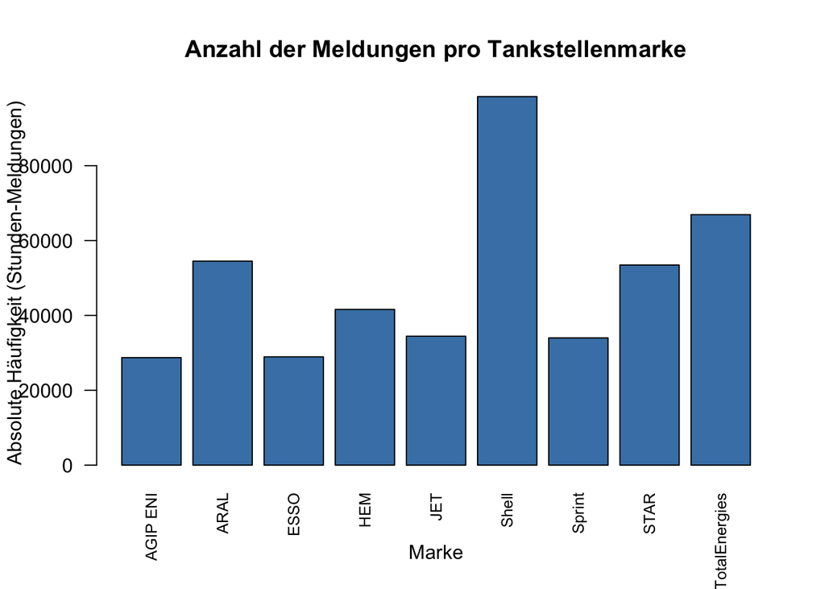

```r
# Balkendiagramm zeichnen
barplot(abs_freq_brand,
        main = "Anzahl der Meldungen pro Tankstellenmarke",
        xlab = "Marke",
        ylab = "Absolute Häufigkeit (Stunden-Meldungen)",
        col = "steelblue",
        las = 2,           # Dreht die Beschriftung der x-Achse um 90 Grad
        cex.names = 0.8)   # Macht die Schrift der Achse etwas kleiner
```

**f. Was bedeuten die absoluten Häufigkeiten im Kontext unserer Daten? Warum gibt es Unterschiede zwischen den Werten der verschiedenen Marken?**

Die absoluten Häufigkeiten geben nicht nur die reine Anzahl der Tankstellen pro Marke an. Da unsere Merkmalsträger eine Kombination aus “Tankstelle” und “Stunde” sind, zeigt die absolute Häufigkeit, wie viele stündliche Preismeldungen insgesamt von einer bestimmten Marke im Datensatz vorliegen.

**Unterschiede zwischen den Marken** kommen hauptsächlich durch zwei Dinge zustande: 1. Unterschiedliche Marktanteile: Große Anbieter (wie Aral oder Shell) haben deutlich mehr Tankstellen in Berlin als kleinere Anbieter. Mehr Tankstellen produzieren pro Stunde auch mehr Datensätze.

2. Öffnungszeiten und Verfügbarkeit: Wenn Tankstellen nachts geschlossen sind oder ihre Preise nicht durchgehend übermitteln, fehlen für diese Stunden die Meldungen. Marken mit vielen 24/7-Tankstellen generieren also verhältnismäßig mehr Datensätze.

## Woche 2 – 12.05.2026

**a. Bestimmen Sie, wie viele Werte bei jedem Merkmal im Datensatz fehlen (NA). Finden Sie mit etwas Detektivarbeit heraus, welche Eigenschaft die Datensätze mit den fehlenden Werten haben und wie man die fehlenden mit sinnvollen Werten ersetzen kann. Das Ersetzen müssen Sie nur erklären, nicht implementieren.**

Zuerst zählen wir für jedes Merkmal, wie viele Einträge fehlen. Dafür verwenden wir `is.na()` für jede Spalte und summieren die TRUE-Werte.

```r
fehlende_werte <- colSums(is.na(tankerkoenig))

data.frame(
  Merkmal = names(fehlende_werte),
  Fehlende_Werte = as.numeric(fehlende_werte)
)
```

```
##          Merkmal Fehlende_Werte
## 1              X              0
## 2             id              0
## 3           date              0
## 4           time              0
## 5           name              0
## 6          brand              0
## 7         street              0
## 8   house_number          75148
## 9      post_code              0
## 10  opening_time              0
## 11  closing_time              0
## 12    e10_median            811
## 13 diesel_median              0
```

Die fehlenden Werte treten nur bei `house_number` und `e10_median` auf. Um die Ursache genauer zu verstehen, betrachten wir die betroffenen Tankstellen.

```r
# Tankstellen mit fehlender Hausnummer
unique(tankerkoenig[is.na(tankerkoenig$house_number),
                    c("id", "name", "brand", "street", "post_code")])
```

```
##                                         id
## 1     005056ba-7cb6-1ed2-bceb-6dbab19bed20
## 5639  005056ba-7cb6-1ed2-bceb-6e844f9e6d20
## 10795 005056ba-7cb6-1ed2-bceb-8e5fec1a0d35
## 17348 005056ba-7cb6-1ed2-bceb-8f11d216cd35
## 22894 005056ba-7cb6-1ed2-bceb-aba199748d43
## 29403 005056ba-7cb6-1ed5-a6a1-930ae49a5411
## 35730 005056ba-7cb6-1ee5-a980-090160c05099
## 41428 005056ba-7cb6-1ee5-b187-bc79c0a8d9ec
## 48010 005056ba-7cb6-1ee5-b791-639597361b11
## 53462 01abf2e9-84e2-4328-936f-9958c7c733a8
## 59157 0591a60a-a167-4cc5-a200-c21d4a1e698e
## 64093 1b25d42b-65e8-4724-a801-6a921b273aa7
## 69507 1c002618-6ca6-4faf-9752-688a83b5e818
##                                           name brand
```

[output cut: 27 more lines]

```r
# Tankstelle(n) mit fehlendem E10-Preis
unique(tankerkoenig[is.na(tankerkoenig$e10_median),
                    c("id", "name", "brand", "street",
                      "house_number", "post_code")])
```

```
##                                          id                          name brand
## 374449 defadb89-ee11-459a-9ce5-416df31ee2e8 Shell Berlin Heerstr. 326-328 Shell
##          street house_number post_code
## 374449 Heerstr.      326-328     13593
```

```r
# Zeitraum der fehlenden E10-Werte
range(tankerkoenig$date[is.na(tankerkoenig$e10_median)])
```

```
## [1] "2025-08-07" "2025-09-30"
```

Bei `house_number` sieht man, dass die Hausnummer nicht wirklich unbekannt ist. Sie steht bei diesen Datensätzen bereits im Merkmal `street`, zum Beispiel in Einträgen wie `Steglitzer Damm 77`, `Königin-Luise-Straße 22a` oder `Prenzlauer Promenade 72-73`. Sinnvoll wäre deshalb, die Hausnummer aus dem Ende des Straßennamens zu übernehmen und das Merkmal `street` danach auf den reinen Straßennamen zu kürzen.

Die fehlenden Werte bei `e10_median` gehören alle zu einer einzelnen Shell-Tankstelle: `Shell Berlin Heerstr. 326-328`. Der Zeitraum reicht vom 07.08.2025 bis zum 30.09.2025. Für diese Zeilen ist `diesel_median` vorhanden, nur der E10-Wert fehlt. Sinnvoll wäre hier eine Schätzung aus den vorhandenen Daten derselben Tankstelle, zum Beispiel indem man für diese Tankstelle die typische Differenz `e10_median - diesel_median` in den übrigen Zeitpunkten berechnet und diese Differenz auf die vorhandenen Dieselpreise addiert. Noch genauer wäre eine Differenz nach Uhrzeit, weil Kraftstoffpreise im Tagesverlauf schwanken.

**b. Erstellen Sie Histogramme für die Merkmale `e10_median` und `diesel_median` und zeichnen jeweils das arithmetische Mittel und den Median ein.**

Für die Histogramme entfernen wir fehlende E10-Werte mit `na.omit()`. Die Preise sind im Datensatz als ganze Zahlen gespeichert, zum Beispiel 1769 für 1,769 Euro. Für die Lagewerte spielt diese Skalierung keine Rolle, die Achsenbeschriftung weist aber auf diese Einheit hin.

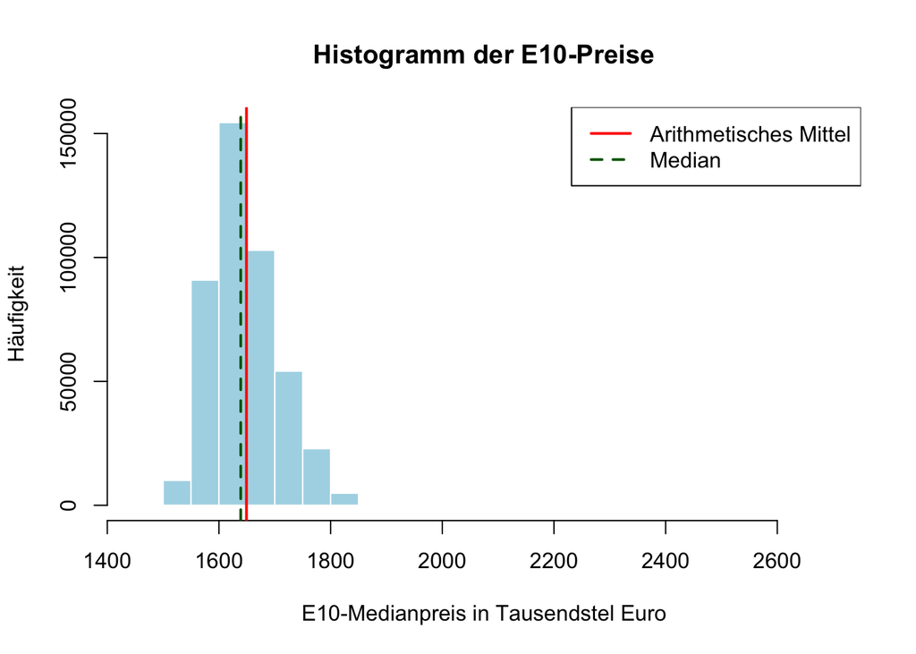

```r
e10_werte <- na.omit(tankerkoenig$e10_median)
e10_mittel <- mean(e10_werte)
e10_median <- median(e10_werte)

hist(e10_werte,
     main = "Histogramm der E10-Preise",
     xlab = "E10-Medianpreis in Tausendstel Euro",
     ylab = "Häufigkeit",
     col = "lightblue",
     border = "white")

abline(v = e10_mittel, col = "red", lwd = 2)
abline(v = e10_median, col = "darkgreen", lwd = 2, lty = 2)
legend("topright",
       legend = c("Arithmetisches Mittel", "Median"),
       col = c("red", "darkgreen"),
       lwd = 2,
       lty = c(1, 2))
```

Beim E10-Preis liegt das arithmetische Mittel etwas oberhalb des Medians. Das deutet darauf hin, dass einige höhere Preise den Durchschnitt nach oben ziehen.

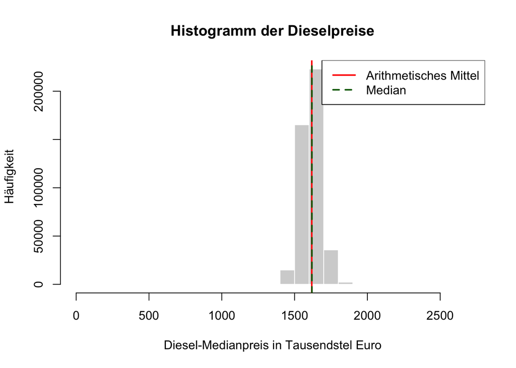

```r
diesel_werte <- tankerkoenig$diesel_median
diesel_mittel <- mean(diesel_werte)
diesel_median_wert <- median(diesel_werte)

hist(diesel_werte,
     main = "Histogramm der Dieselpreise",
     xlab = "Diesel-Medianpreis in Tausendstel Euro",
     ylab = "Häufigkeit",
     col = "lightgray",
     border = "white")

abline(v = diesel_mittel, col = "red", lwd = 2)
abline(v = diesel_median_wert, col = "darkgreen", lwd = 2, lty = 2)
legend("topright",
       legend = c("Arithmetisches Mittel", "Median"),
       col = c("red", "darkgreen"),
       lwd = 2,
       lty = c(1, 2))
```

Beim Dieselpreis liegen arithmetisches Mittel und Median sehr nah beieinander. Die Verteilung ist dadurch im Zentrum ungefähr ausgeglichen.

**c. Finden Sie heraus, wie man zwei Histogramme zum besseren Vergleich in einem Diagramm überlagern kann. Dazu können Sie auch Bibliotheken wie ggplot2 und plotly betrachten.**

Zwei Histogramme kann man überlagern, indem man für beide Merkmale dieselben Klassengrenzen verwendet und halbtransparente Farben setzt. Dadurch bleiben die Bereiche sichtbar, in denen sich die Verteilungen überschneiden.

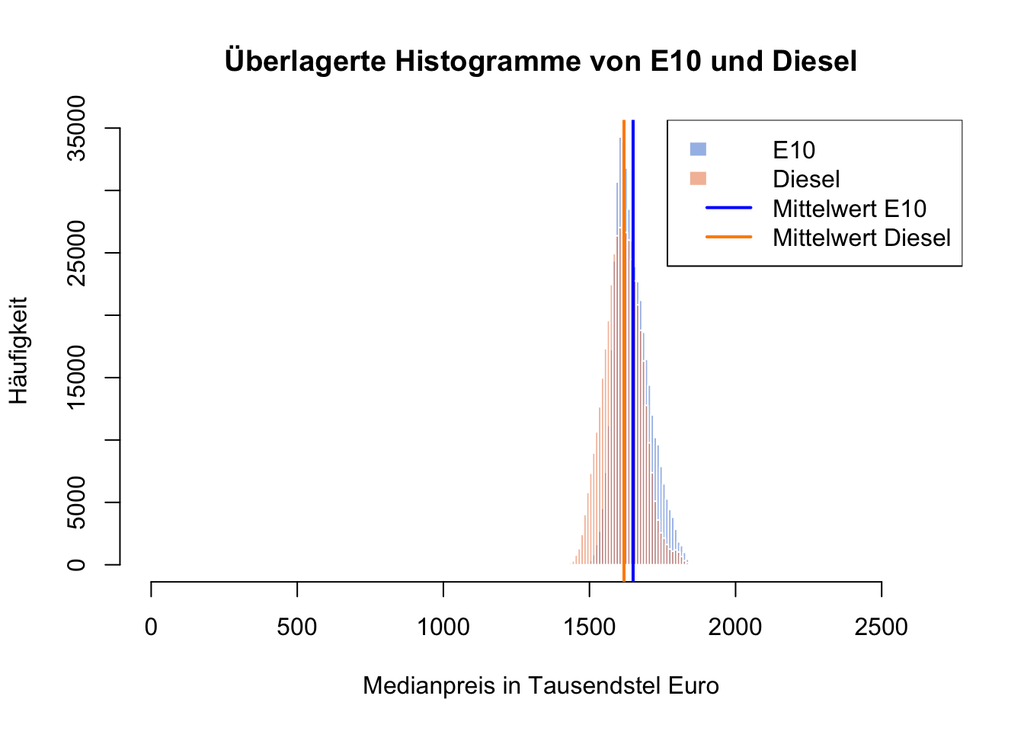

```r
gemeinsame_grenzen <- seq(
  floor(min(c(e10_werte, diesel_werte), na.rm = TRUE) / 10) * 10,
  ceiling(max(c(e10_werte, diesel_werte), na.rm = TRUE) / 10) * 10,
  by = 10
)

hist(e10_werte,
     breaks = gemeinsame_grenzen,
     col = rgb(0.1, 0.4, 0.8, 0.45),
     border = "white",
     main = "Überlagerte Histogramme von E10 und Diesel",
     xlab = "Medianpreis in Tausendstel Euro",
     ylab = "Häufigkeit")

hist(diesel_werte,
     breaks = gemeinsame_grenzen,
     col = rgb(0.9, 0.4, 0.1, 0.45),
     border = "white",
     add = TRUE)

abline(v = e10_mittel, col = "blue", lwd = 2)
abline(v = diesel_mittel, col = "darkorange", lwd = 2)

legend("topright",
       legend = c("E10", "Diesel", "Mittelwert E10", "Mittelwert Diesel"),
       fill = c(rgb(0.1, 0.4, 0.8, 0.45),
                rgb(0.9, 0.4, 0.1, 0.45),
                NA,
                NA),
       border = c("white", "white", NA, NA),
       col = c(NA, NA, "blue", "darkorange"),
       lwd = c(NA, NA, 2, 2))
```

Im überlagerten Histogramm erkennt man, dass die E10-Preise insgesamt etwas höher liegen als die Dieselpreise. Die beiden Verteilungen überschneiden sich aber stark, weil beide Kraftstoffarten ähnlichen Markt- und Tagespreisschwankungen unterliegen.

## Woche 3 – 19.05.2026

**a. Bestimmen Sie Fünf- oder Sechs-Punkte-Zusammenfassungen der Merkmale `e10_median` und `diesel_median` und erstellen zugehörige Boxplots mit Ausreißererkennung. Beschreiben Sie anhand dessen die Unterschiede zwischen den Werteverteilungen der Merkmale.**

Zuerst bestimmen wir für beide Kraftstoffarten die Sechs-Punkte-Zusammenfassung mit Minimum, erstem Quartil, Median, arithmetischem Mittel, drittem Quartil und Maximum. Fehlende Werte bei `e10_median` werden dabei entfernt.

```r
e10_werte <- na.omit(tankerkoenig$e10_median)
diesel_werte <- na.omit(tankerkoenig$diesel_median)

zusammenfassung_preise <- data.frame(
  Merkmal = c("E10", "Diesel"),
  Minimum = c(min(e10_werte), min(diesel_werte)),
  Q1 = c(quantile(e10_werte, 0.25), quantile(diesel_werte, 0.25)),
  Median = c(median(e10_werte), median(diesel_werte)),
  Mittelwert = c(mean(e10_werte), mean(diesel_werte)),
  Q3 = c(quantile(e10_werte, 0.75), quantile(diesel_werte, 0.75)),
  Maximum = c(max(e10_werte), max(diesel_werte))
)

zusammenfassung_preise
```

```
##   Merkmal Minimum   Q1 Median Mittelwert   Q3 Maximum
## 1     E10    1484 1609   1639   1649.274 1689    2669
## 2  Diesel       0 1574   1619   1618.157 1659    2619
```

Für die Boxplots verwenden wir die übliche 1,5-IQR-Regel. Werte außerhalb der Antennen werden im Boxplot als Ausreißer dargestellt.

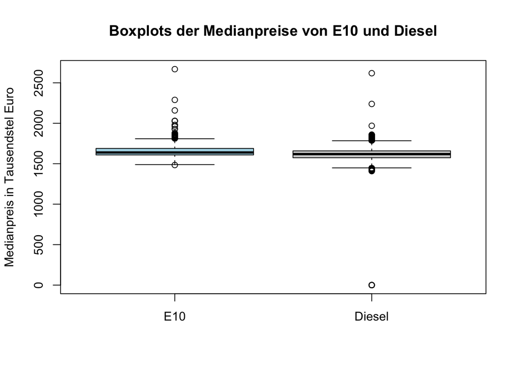

```r
boxplot(e10_werte, diesel_werte,
        names = c("E10", "Diesel"),
        main = "Boxplots der Medianpreise von E10 und Diesel",
        ylab = "Medianpreis in Tausendstel Euro",
        col = c("lightblue", "lightgray"))
```

Die mittleren 50 % der E10-Werte liegen zwischen 1609 und 1689, bei Diesel zwischen 1574 und 1659. E10 liegt damit im Zentrum der Verteilung etwas höher als Diesel. Der Median beträgt bei E10 1639 und bei Diesel 1619. Beide Verteilungen haben Ausreißer nach unten und oben. Besonders auffällig ist bei Diesel das Minimum 0, denn ein Dieselpreis von 0 ist fachlich kein realistischer Kraftstoffpreis. Bei E10 ist das Maximum 2669 ebenfalls extrem hoch gegenüber dem normalen Wertebereich.

**b. Extrahieren Sie die Ausreißer von `e10_median` und `diesel_median`. Finden Sie mit Detektivarbeit heraus, ob es ein Muster für die Ausreißer gibt, z.B. wann sie wo auftreten, und ob die Ausreißer echte oder falsche Werte sind.**

Wir berechnen zunächst die unteren und oberen Ausreißergrenzen nach der 1,5-IQR-Regel und filtern anschließend alle betroffenen Datensätze heraus.

```r
ausreisser_grenzen <- function(x) {
  x <- x[!is.na(x)]
  q1 <- quantile(x, 0.25)
  q3 <- quantile(x, 0.75)
  iqr <- IQR(x)
  c(unten = q1 - 1.5 * iqr,
    oben = q3 + 1.5 * iqr)
}

grenzen_e10 <- ausreisser_grenzen(tankerkoenig$e10_median)
grenzen_diesel <- ausreisser_grenzen(tankerkoenig$diesel_median)

ausreisser_e10 <- tankerkoenig[
  !is.na(tankerkoenig$e10_median) &
    (tankerkoenig$e10_median < grenzen_e10["unten"] |
       tankerkoenig$e10_median > grenzen_e10["oben"]),
]

ausreisser_diesel <- tankerkoenig[
  !is.na(tankerkoenig$diesel_median) &
    (tankerkoenig$diesel_median < grenzen_diesel["unten"] |
       tankerkoenig$diesel_median > grenzen_diesel["oben"]),
]

data.frame(
  Merkmal = c("E10", "Diesel"),
  Untere_Grenze = c(grenzen_e10["unten"], grenzen_diesel["unten"]),
  Obere_Grenze = c(grenzen_e10["oben"], grenzen_diesel["oben"]),
  Anzahl_Ausreisser = c(nrow(ausreisser_e10), nrow(ausreisser_diesel))
)
```

```
##   Merkmal Untere_Grenze Obere_Grenze Anzahl_Ausreisser
## 1     E10            NA           NA            440267
## 2  Diesel            NA           NA            441078
```

Um Muster zu finden, betrachten wir die Ausreißer nach Monat, Uhrzeit und Marke. Außerdem lassen wir uns die extremsten Beobachtungen anzeigen.

```r
# Monate mit den meisten Ausreißern
sort(table(substr(ausreisser_e10$date, 1, 7)), decreasing = TRUE)[1:6]
```

```
## [1] NA NA NA NA NA NA
```

```r
sort(table(substr(ausreisser_diesel$date, 1, 7)), decreasing = TRUE)[1:6]
```

```
## [1] NA NA NA NA NA NA
```

```r
# Uhrzeiten mit den meisten Ausreißern
sort(table(ausreisser_e10$time), decreasing = TRUE)[1:8]
```

```
## [1] NA NA NA NA NA NA NA NA
```

```r
sort(table(ausreisser_diesel$time), decreasing = TRUE)[1:8]
```

```
## [1] NA NA NA NA NA NA NA NA
```

```r
# Marken mit den meisten Ausreißern
sort(table(ausreisser_e10$brand), decreasing = TRUE)[1:8]
```

```
## [1] NA NA NA NA NA NA NA NA
```

```r
sort(table(ausreisser_diesel$brand), decreasing = TRUE)[1:8]
```

```
## [1] NA NA NA NA NA NA NA NA
```

```r
auswahl_spalten <- c("date", "time", "name", "brand", "street",
                     "house_number", "post_code", "e10_median",
                     "diesel_median")

# Größte E10-Ausreißer
head(ausreisser_e10[order(-ausreisser_e10$e10_median),
                    auswahl_spalten], 12)
```

[output not shown]

```r
# Kleinste E10-Ausreißer
head(ausreisser_e10[order(ausreisser_e10$e10_median),
                    auswahl_spalten], 8)
```

[output not shown]

```r
# Größte Diesel-Ausreißer
head(ausreisser_diesel[order(-ausreisser_diesel$diesel_median),
                       auswahl_spalten], 12)
```

[output not shown]

```r
# Kleinste Diesel-Ausreißer
head(ausreisser_diesel[order(ausreisser_diesel$diesel_median),
                       auswahl_spalten], 12)
```

[output not shown]

**c. Berechnen Sie die mittlere absolute Abweichung vom arithmetischen Mittel und die Standardabweichung von `e10_median` und `diesel_median` und vergleichen die Werte.**

Die mittlere absolute Abweichung berechnen wir hier als durchschnittlichen absoluten Abstand aller Werte vom arithmetischen Mittel. Die Standardabweichung misst ebenfalls Streuung, gewichtet große Abweichungen wegen des Quadrierens aber stärker.

```r
mittlere_absolute_abweichung <- function(x) {
  x <- x[!is.na(x)]
  mean(abs(x - mean(x)))
}

streuung_preise <- data.frame(
  Merkmal = c("E10", "Diesel"),
  Mittlere_absolute_Abweichung = c(
    mittlere_absolute_abweichung(tankerkoenig$e10_median),
    mittlere_absolute_abweichung(tankerkoenig$diesel_median)
  ),
  Standardabweichung = c(
    sd(tankerkoenig$e10_median, na.rm = TRUE),
    sd(tankerkoenig$diesel_median, na.rm = TRUE)
  )
)

streuung_preise
```

```
##   Merkmal Mittlere_absolute_Abweichung Standardabweichung
## 1     E10                     47.89162           59.45331
## 2  Diesel                     51.05878           64.31796
```

## Woche 4 – 26.05.2026

**a. Wochentag-Spalte und Boxplots nach Wochentag**

Um den Wochentag zu bestimmen, nutzen wir `format(as.Date(...), "%u")` statt `weekdays()`, weil letzteres je nach Systemsprache englische oder deutsche Namen liefert und das auf anderen Rechnern zu Fehlern führen kann. `%u` gibt immer eine Zahl zurück (1 = Montag, 7 = Sonntag), und wir weisen die deutschen Namen dann selbst zu. Danach machen wir die Spalte zu einem geordneten Faktor, damit die Boxplots von Montag bis Sonntag sortiert erscheinen.

```r
# Wochentag locale-unabhaengig ueber ISO-Nummer ableiten:
# %u liefert 1 (Montag) bis 7 (Sonntag) - unabhaengig von der Systemsprache
wt_nummer <- as.integer(format(as.Date(tankerkoenig$date), "%u"))

# Deutsche Bezeichnungen manuell zuweisen
wochentag_reihenfolge <- c("Montag", "Dienstag", "Mittwoch",
                            "Donnerstag", "Freitag", "Samstag", "Sonntag")
tankerkoenig$wochentag <- factor(wochentag_reihenfolge[wt_nummer],
                                  levels = wochentag_reihenfolge,
                                  ordered = TRUE)

# Ueberpruefung: erste Zeilen mit neuem Merkmal
head(tankerkoenig[, c("date", "wochentag", "e10_median", "diesel_median")])
```

```
##         date wochentag e10_median diesel_median
## 1 2025-02-01   Samstag       1769          1709
## 2 2025-02-01   Samstag       1799          1719
## 3 2025-02-01   Samstag       1779          1669
## 4 2025-02-01   Samstag       1699          1609
## 5 2025-02-01   Samstag       1689          1629
## 6 2025-02-01   Samstag       1699          1619
```

Die sieben Boxplots für E10 und Diesel zeichnen wir jeweils nebeneinander. Mit `par(mfrow = c(1,2))` kommen beide Plots in eine Zeile, `outline = FALSE` blendet Ausreißer aus, damit die Boxen selbst besser lesbar sind.

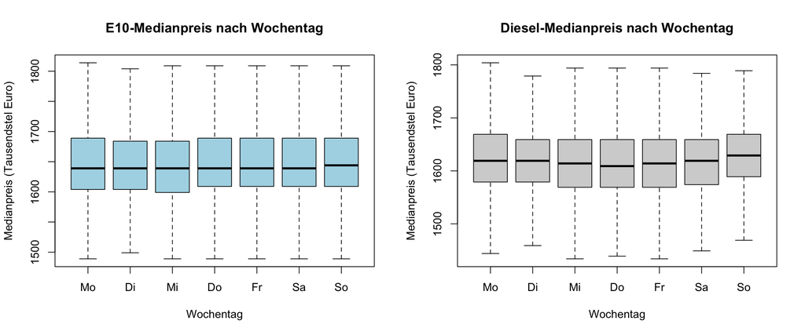

```r
# Kurzbezeichnungen für die x-Achse
wt_kurz <- c("Mo", "Di", "Mi", "Do", "Fr", "Sa", "So")

par(mfrow = c(1, 2))   # zwei Plots nebeneinander

boxplot(e10_median ~ wochentag, data = tankerkoenig,
        main = "E10-Medianpreis nach Wochentag",
        xlab = "Wochentag", ylab = "Medianpreis (Tausendstel Euro)",
        col = "lightblue", names = wt_kurz,
        outline = FALSE)   # Ausreißer ausblenden für bessere Übersicht

boxplot(diesel_median ~ wochentag, data = tankerkoenig,
        main = "Diesel-Medianpreis nach Wochentag",
        xlab = "Wochentag", ylab = "Medianpreis (Tausendstel Euro)",
        col = "lightgray", names = wt_kurz,
        outline = FALSE)
```

```r
par(mfrow = c(1, 1))
```

```r
# Absolute Preisunterschiede zwischen Wochentagen messen
wt_stats_e10 <- tapply(tankerkoenig$e10_median, tankerkoenig$wochentag, median, na.rm = TRUE)
wt_stats_diesel <- tapply(tankerkoenig$diesel_median, tankerkoenig$wochentag, median, na.rm = TRUE)

wt_vergleich <- data.frame(
  Wochentag = wochentag_reihenfolge,
  E10_Median = round(wt_stats_e10, 1),
  Diesel_Median = round(wt_stats_diesel, 1)
)
wt_vergleich$E10_Diff_zum_Mo   <- round(wt_vergleich$E10_Median - wt_vergleich$E10_Median[1], 1)
wt_vergleich$Diesel_Diff_zum_Mo <- round(wt_vergleich$Diesel_Median - wt_vergleich$Diesel_Median[1], 1)
wt_vergleich
```

```
##             Wochentag E10_Median Diesel_Median E10_Diff_zum_Mo
## Montag         Montag       1639          1619               0
## Dienstag     Dienstag       1639          1619               0
## Mittwoch     Mittwoch       1639          1614               0
## Donnerstag Donnerstag       1639          1609               0
## Freitag       Freitag       1639          1614               0
## Samstag       Samstag       1639          1619               0
## Sonntag       Sonntag       1644          1629               5
##            Diesel_Diff_zum_Mo
## Montag                      0
## Dienstag                    0
## Mittwoch                   -5
## Donnerstag                -10
## Freitag                    -5
## Samstag                     0
## Sonntag                    10
```

**b. Boxplots nach Uhrzeit**

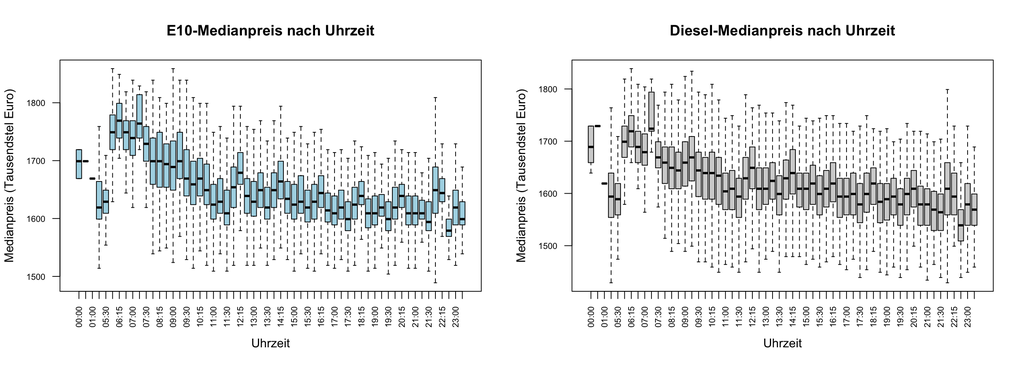

```r
# time als geordneten Faktor definieren
uhrzeiten <- sort(unique(tankerkoenig$time))
tankerkoenig$time_f <- factor(tankerkoenig$time, levels = uhrzeiten, ordered = TRUE)

par(mfrow = c(1, 2))

boxplot(e10_median ~ time_f, data = tankerkoenig,
        main = "E10-Medianpreis nach Uhrzeit",
        xlab = "Uhrzeit", ylab = "Medianpreis (Tausendstel Euro)",
        col = "lightblue", las = 2, cex.axis = 0.7,
        outline = FALSE)

boxplot(diesel_median ~ time_f, data = tankerkoenig,
        main = "Diesel-Medianpreis nach Uhrzeit",
        xlab = "Uhrzeit", ylab = "Medianpreis (Tausendstel Euro)",
        col = "lightgray", las = 2, cex.axis = 0.7,
        outline = FALSE)
```

```r
par(mfrow = c(1, 1))
```

```r
# Mediane pro Stunde für beide Kraftstoffe
uh_stats_e10   <- tapply(tankerkoenig$e10_median, tankerkoenig$time_f, median, na.rm = TRUE)
uh_stats_diesel <- tapply(tankerkoenig$diesel_median, tankerkoenig$time_f, median, na.rm = TRUE)

uh_vergleich <- data.frame(
  Uhrzeit = uhrzeiten,
  E10_Median = round(uh_stats_e10, 1),
  Diesel_Median = round(uh_stats_diesel, 1)
)

# Spanne (Maximum - Minimum) als Maß für den täglichen Schwankungsbereich
cat("E10   – Spanne über den Tag (Max–Min der stündl. Mediane):",
    round(max(uh_stats_e10, na.rm=TRUE) - min(uh_stats_e10, na.rm=TRUE), 1), "\n")
```

```
## E10   – Spanne über den Tag (Max–Min der stündl. Mediane): 190
```

```r
cat("Diesel – Spanne über den Tag (Max–Min der stündl. Mediane):",
    round(max(uh_stats_diesel, na.rm=TRUE) - min(uh_stats_diesel, na.rm=TRUE), 1), "\n")
```

```
## Diesel – Spanne über den Tag (Max–Min der stündl. Mediane): 190
```

```r
uh_vergleich
```

```
##       Uhrzeit E10_Median Diesel_Median
## 00:00   00:00       1699          1689
## 00:30   00:30       1699          1729
## 01:00   01:00       1669          1619
## 05:00   05:00       1619          1594
## 05:30   05:30       1629          1589
## 06:00   06:00       1749          1699
## 06:15   06:15       1769          1719
## 06:30   06:30       1749          1689
## 07:00   07:00       1739          1679
## 07:15   07:15       1764          1724
## 07:30   07:30       1729          1669
## 08:00   08:00       1699          1659
## 08:15   08:15       1699          1649
## 08:30   08:30       1694          1644
## 09:00   09:00       1689          1659
## 09:15   09:15       1699          1669
## 09:30   09:30       1669          1644
## 10:00   10:00       1659          1639
## 10:15   10:15       1669          1639
## 10:30   10:30       1649          1634
## 11:00   11:00       1624          1604
## 11:15   11:15       1629          1609
## 11:30   11:30       1609          1594
## 12:00   12:00       1654          1629
## 12:15   12:15       1679          1649
## 12:30   12:30       1639          1609
## 13:00   13:00       1629          1609
## 13:15   13:15       1649          1624
## 13:30   13:30       1619          1599
## 14:00   14:00       1649          1629
## 14:15   14:15       1664          1639
## 14:30   14:30       1634          1609
## 15:00   15:00       1624          1609
## 15:15   15:15       1629          1619
## 15:30   15:30       1619          1599
## 16:00   16:00       1629          1609
## 16:15   16:15       1644          1619
## 16:30   16:30       1614          1594
## 17:00   17:00       1609          1594
## 17:15   17:15       1619          1599
## 17:30   17:30       1599          1579
## 18:00   18:00       1624          1599
## 18:15   18:15       1639          1619
## 18:30   18:30       1609          1584
## 19:00   19:00       1609          1589
## 19:15   19:15       1619          1594
## 19:30   19:30       1599          1579
## 20:00   20:00       1619          1599
## 20:15   20:15       1639          1609
## 20:30   20:30       1609          1579
## 21:00   21:00       1609          1579
## 21:15   21:15       1609          1569
## 21:30   21:30       1594          1564
## 22:00   22:00       1649          1609
## 22:15   22:15       1644          1594
## 22:30   22:30       1579          1539
## 23:00   23:00       1619          1579
## 23:30   23:30       1599          1569
```

**c. Boxplots nach Marke**

Zuletzt schauen wir uns die Preise nach Marke an. Weil es viele verschiedene Marken gibt, sortieren wir sie nach ihrem E10-Median und drehen die Achsenbeschriftung, damit alles lesbar bleibt.

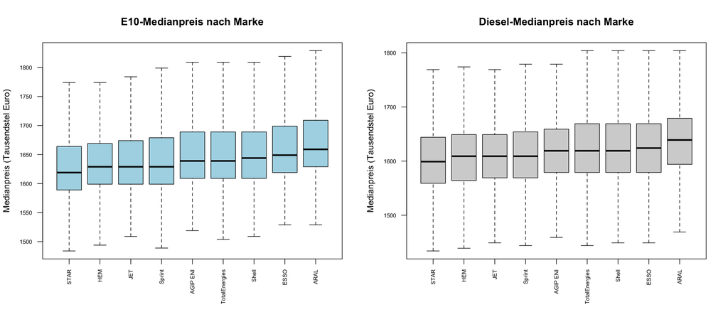

```r
# Marken nach medianem E10-Preis sortieren für bessere Lesbarkeit
marken_mediane_e10 <- tapply(tankerkoenig$e10_median, tankerkoenig$brand, median, na.rm = TRUE)
marken_order <- names(sort(marken_mediane_e10))

tankerkoenig$brand_f <- factor(tankerkoenig$brand, levels = marken_order)

par(mfrow = c(1, 2))

boxplot(e10_median ~ brand_f, data = tankerkoenig,
        main = "E10-Medianpreis nach Marke",
        xlab = "", ylab = "Medianpreis (Tausendstel Euro)",
        col = "lightblue", las = 2, cex.axis = 0.65,
        outline = FALSE)

boxplot(diesel_median ~ brand_f, data = tankerkoenig,
        main = "Diesel-Medianpreis nach Marke",
        xlab = "", ylab = "Medianpreis (Tausendstel Euro)",
        col = "lightgray", las = 2, cex.axis = 0.65,
        outline = FALSE)
```

```r
par(mfrow = c(1, 1))
```

```r
# Mediane pro Marke
mk_stats_e10    <- sort(tapply(tankerkoenig$e10_median, tankerkoenig$brand, median, na.rm = TRUE))
mk_stats_diesel <- tapply(tankerkoenig$diesel_median, tankerkoenig$brand, median, na.rm = TRUE)
mk_stats_diesel <- mk_stats_diesel[names(mk_stats_e10)]  # gleiche Reihenfolge

mk_vergleich <- data.frame(
  Marke = names(mk_stats_e10),
  E10_Median = round(mk_stats_e10, 1),
  Diesel_Median = round(mk_stats_diesel, 1)
)

cat("E10   – Spanne über Marken (teuerste − günstigste):",
    round(max(mk_stats_e10, na.rm=TRUE) - min(mk_stats_e10, na.rm=TRUE), 1), "\n")
```

```
## E10   – Spanne über Marken (teuerste − günstigste): 40
```

```r
cat("Diesel – Spanne über Marken (teuerste − günstigste):",
    round(max(mk_stats_diesel, na.rm=TRUE) - min(mk_stats_diesel, na.rm=TRUE), 1), "\n")
```

```
## Diesel – Spanne über Marken (teuerste − günstigste): 40
```

```r
mk_vergleich
```

```
##                       Marke E10_Median Diesel_Median
## STAR                   STAR       1619          1599
## HEM                     HEM       1629          1609
## JET                     JET       1629          1609
## Sprint               Sprint       1629          1609
## AGIP ENI           AGIP ENI       1639          1619
## TotalEnergies TotalEnergies       1639          1619
## Shell                 Shell       1644          1619
## ESSO                   ESSO       1649          1624
## ARAL                   ARAL       1659          1639
```

Die Unterschiede zwischen den Marken sind gut sichtbar. Große Markentankstellen wie Aral oder Shell verlangen tendenziell mehr, während JET und freie Tankstellen günstiger sind. Die Spanne zwischen der günstigsten und teuersten Marke ist bei beiden Kraftstoffen größer als die Schwankungen über die Wochentage.

**d. Stärkster Einflussfaktor auf die Kraftstoffpreise**

Um die drei Merkmale direkt vergleichen zu können, fassen wir die jeweiligen Spannen der Gruppen-Mediane in einer Tabelle zusammen.

```r
# Zusammenfassung der Spannen aller drei Merkmale
spanne_e10_wt     <- round(max(wt_stats_e10, na.rm=TRUE) - min(wt_stats_e10, na.rm=TRUE), 1)
spanne_e10_uh     <- round(max(uh_stats_e10, na.rm=TRUE) - min(uh_stats_e10, na.rm=TRUE), 1)
spanne_e10_mk     <- round(max(mk_stats_e10, na.rm=TRUE) - min(mk_stats_e10, na.rm=TRUE), 1)

spanne_diesel_wt  <- round(max(wt_stats_diesel, na.rm=TRUE) - min(wt_stats_diesel, na.rm=TRUE), 1)
spanne_diesel_uh  <- round(max(uh_stats_diesel, na.rm=TRUE) - min(uh_stats_diesel, na.rm=TRUE), 1)
spanne_diesel_mk  <- round(max(mk_stats_diesel, na.rm=TRUE) - min(mk_stats_diesel, na.rm=TRUE), 1)

vergleich_einfluss <- data.frame(
  Merkmal    = c("Wochentag", "Uhrzeit", "Marke"),
  E10_Spanne   = c(spanne_e10_wt, spanne_e10_uh, spanne_e10_mk),
  Diesel_Spanne = c(spanne_diesel_wt, spanne_diesel_uh, spanne_diesel_mk)
)
vergleich_einfluss
```

```
##     Merkmal E10_Spanne Diesel_Spanne
## 1 Wochentag          5            20
## 2   Uhrzeit        190           190
## 3     Marke         40            40
```

Den größten Einfluss auf die Kraftstoffpreise hat die **Uhrzeit**. Die Spanne der stündlichen Mediane ist bei E10 wie bei Diesel am größten und deutlich höher als bei den anderen beiden Merkmalen. Wer mittags tankt statt morgens, spart messbar – das zeigen die Boxplots sehr klar.

An zweiter Stelle steht die **Marke**. Auch hier sind die Preisunterschiede gut sichtbar und liegen deutlich über den Wochentags-Schwankungen. Je nach Marke kann man also ebenfalls einiges sparen.

Den geringsten Einfluss hat der **Wochentag**. Die Boxplots sehen von Montag bis Sonntag fast gleich aus, und die Spannen-Tabelle bestätigt das: Die Unterschiede zwischen den Tagen sind im Vergleich zu Uhrzeit und Marke vernachlässigbar.

## Woche 5 – 02.06.2026

**a. Qualitative Preiskategorien für E10 und Diesel**

Für die Einteilung nutzen wir `quantile(..., seq(0, 1, 0.2))`, das uns sechs Grenzwerte liefert, die den Wertebereich in fünf Abschnitte aufteilen. Bei `e10_median` gibt es fehlende Werte, daher `na.rm = TRUE`. Die eigentliche Zuweisung läuft über `cut()` mit `include.lowest = TRUE`, sonst fällt der kleinste Wert raus und bekommt `NA` statt einer Kategorie.

```r
# Quintilsgrenzen berechnen
grenzen_e10    <- quantile(tankerkoenig$e10_median,    seq(0, 1, 0.2), na.rm = TRUE)
grenzen_diesel <- quantile(tankerkoenig$diesel_median, seq(0, 1, 0.2), na.rm = TRUE)

cat("Grenzen E10:\n");    print(grenzen_e10)
```

```
## Grenzen E10:
```

```
##   0%  20%  40%  60%  80% 100%
## 1484 1599 1624 1659 1699 2669
```

```r
cat("Grenzen Diesel:\n"); print(grenzen_diesel)
```

```
## Grenzen Diesel:
```

```
##   0%  20%  40%  60%  80% 100%
##    0 1564 1599 1634 1669 2619
```

```r
# Kategorien in richtiger Reihenfolge
kategorien <- c("sehr niedrig", "niedrig", "mittel", "hoch", "sehr hoch")

# E10: neue qualitative Spalte
tankerkoenig$e10_median_qualitativ <- cut(
  tankerkoenig$e10_median,
  breaks          = grenzen_e10,
  labels          = kategorien,
  include.lowest  = TRUE,
  ordered_result  = TRUE
)

# Diesel: neue qualitative Spalte
tankerkoenig$diesel_median_qualitativ <- cut(
  tankerkoenig$diesel_median,
  breaks          = grenzen_diesel,
  labels          = kategorien,
  include.lowest  = TRUE,
  ordered_result  = TRUE
)

# Ergebnis prüfen
table(tankerkoenig$e10_median_qualitativ)
```

```
##
## sehr niedrig      niedrig       mittel         hoch    sehr hoch
##       101047        75946       102387        78991        81896
```

```r
table(tankerkoenig$diesel_median_qualitativ)
```

```
##
## sehr niedrig      niedrig       mittel         hoch    sehr hoch
##        91248        88852        87090        88068        85820
```

Die Häufigkeiten pro Kategorie sollten ungefähr gleich ausfallen, kleine Unterschiede entstehen aber, wenn mehrere Werte exakt auf einer Grenze liegen.

**b. Warum ist die Einteilung über Quantile sinnvoll?**

Feste Grenzen von Hand zu wählen ist riskant: Je nachdem wie die Daten verteilt sind, können einzelne Kategorien fast leer bleiben und andere sehr voll. Mit Quintilen passiert das nicht, weil die Grenzen direkt aus den Daten kommen und immer ungefähr gleich viele Werte pro Kategorie garantieren. Man kann dann zum Beispiel sagen, ob eine Tankstelle im oberen oder unteren Fünftel liegt – das macht nur Sinn, wenn alle Kategorien ähnlich besetzt sind.

**c. Balkendiagramme der relativen Häufigkeiten**

Die relativen Häufigkeiten holen wir mit `prop.table(table(...))`. Zwei Balkendiagramme nebeneinander machen den direkten Vergleich zwischen E10 und Diesel einfacher.

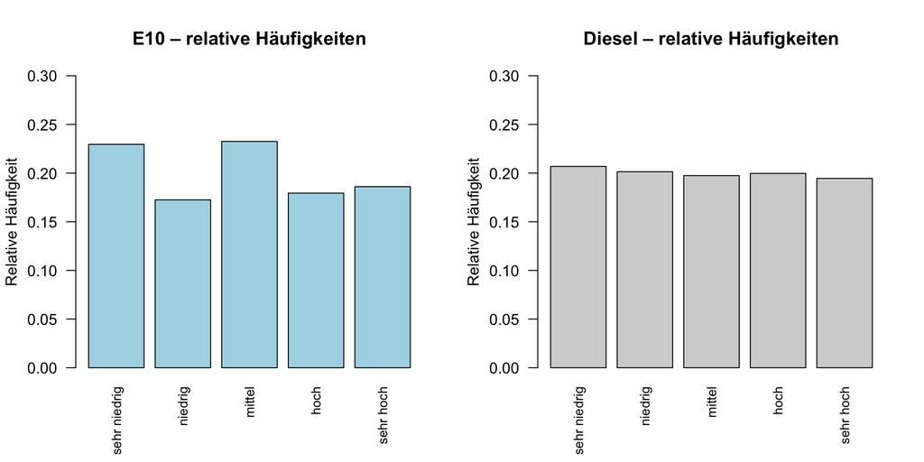

```r
haeuf_e10    <- prop.table(table(tankerkoenig$e10_median_qualitativ))
haeuf_diesel <- prop.table(table(tankerkoenig$diesel_median_qualitativ))

par(mfrow = c(1, 2))

barplot(haeuf_e10,
        main      = "E10 – relative Häufigkeiten",
        ylab      = "Relative Häufigkeit",
        col       = "lightblue",
        ylim      = c(0, 0.30),
        las       = 2,
        cex.names = 0.85)

barplot(haeuf_diesel,
        main      = "Diesel – relative Häufigkeiten",
        ylab      = "Relative Häufigkeit",
        col       = "lightgray",
        ylim      = c(0, 0.30),
        las       = 2,
        cex.names = 0.85)
```

```r
par(mfrow = c(1, 1))
```

Die Balken liegen alle bei etwa 20 % – das war so zu erwarten, weil die Grenzen in Aufgabe a genau dafür berechnet wurden. Anders wäre es nur gewesen, wenn man stattdessen feste Eurowerte als Grenzen genommen hätte, die zufällig nicht gut zum Datensatz passen.

**d. Mosaikplots: Marke und Preiskategorie**

Im Mosaikplot steht die Breite eines Streifens für die Häufigkeit der jeweiligen Marke im Datensatz, die Farbabschnitte darin zeigen wie sich die Preiskategorien innerhalb dieser Marke aufteilen. So sieht man auf einen Blick, ob eine Marke eher im günstigen oder teuren Bereich landet.

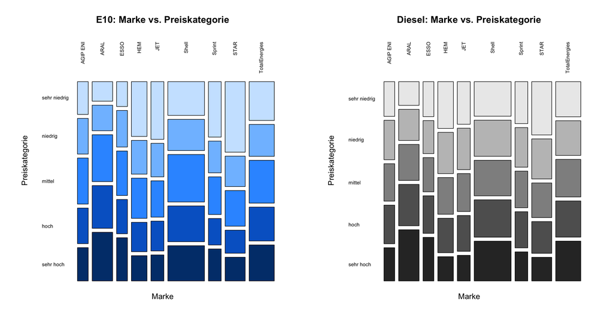

```r
par(mfrow = c(1, 2))

mosaicplot(table(tankerkoenig$brand, tankerkoenig$e10_median_qualitativ),
           main     = "E10: Marke vs. Preiskategorie",
           xlab     = "Marke",
           ylab     = "Preiskategorie",
           col      = c("#cce5ff", "#80bfff", "#3399ff", "#0066cc", "#003d7a"),
           las      = 2,
           cex.axis = 0.65)

mosaicplot(table(tankerkoenig$brand, tankerkoenig$diesel_median_qualitativ),
           main     = "Diesel: Marke vs. Preiskategorie",
           xlab     = "Marke",
           ylab     = "Preiskategorie",
           col      = c("#ebebeb", "#c0c0c0", "#909090", "#606060", "#303030"),
           las      = 2,
           cex.axis = 0.65)
```

```r
par(mfrow = c(1, 1))
```

Man sieht gut, dass die Preisverteilung je nach Marke sehr unterschiedlich aussieht. Bei Aral oder Shell ist der Anteil von *hoch* und *sehr hoch* merklich größer, bei JET oder freien Tankstellen liegt der Schwerpunkt eher unten. Das passt zu dem, was die Boxplots in Woche 4 schon gezeigt haben.

Interessant ist, dass die Reihenfolge der Marken bei E10 und Diesel nahezu identisch ist. Wer bei einem Kraftstoff teuer ist, ist es beim anderen auch – die Marke scheint also grundsätzlich die Preislage zu bestimmen, unabhängig vom Kraftstofftyp.

## Woche 6 – 09.06.2026

**a. Relative Häufigkeiten von `e10_median_qualitativ = sehr hoch` und `diesel_median_qualitativ = sehr hoch` pro Marke**

Wir berechnen für jede Marke, wie groß der Anteil der Beobachtungen mit der Kategorie *sehr hoch* ist. Dazu teilen wir die absolute Häufigkeit von *sehr hoch* durch die Gesamtzahl der Beobachtungen je Marke. Das Ergebnis stellen wir als Balkendiagramm dar, sortiert nach dem E10-Anteil, damit die Marken vergleichbar sind.

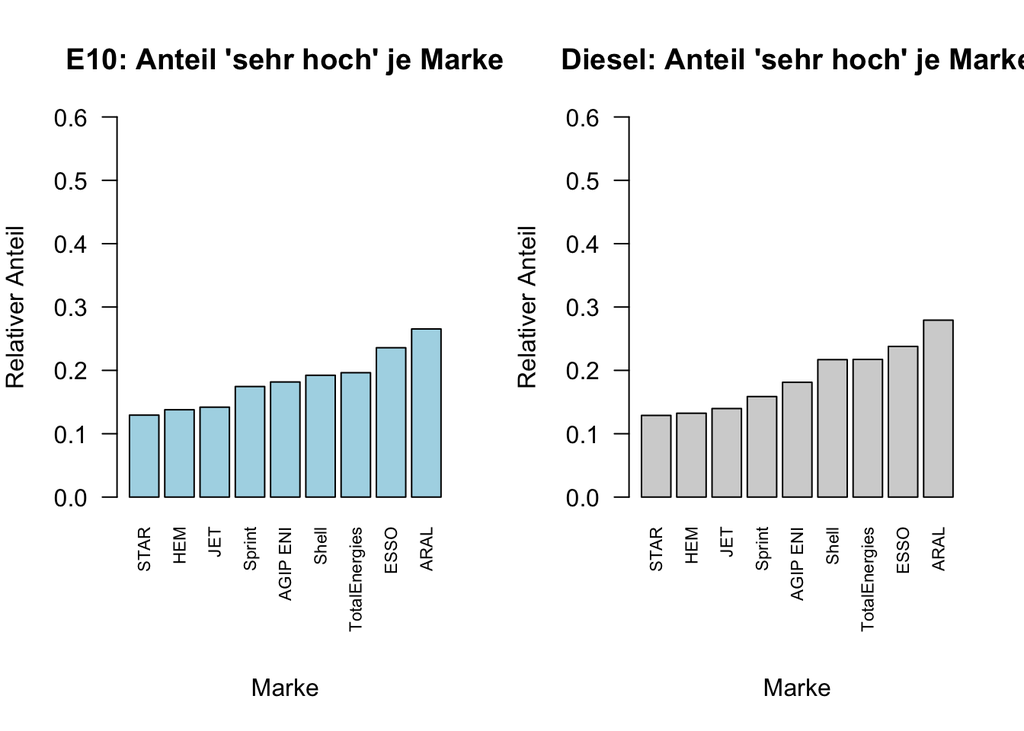

```r
# Kontingenztabellen: Marke x Preiskategorie
tab_e10    <- table(tankerkoenig$brand, tankerkoenig$e10_median_qualitativ)
tab_diesel <- table(tankerkoenig$brand, tankerkoenig$diesel_median_qualitativ)

# Relative Häufigkeiten zeilenweise (= innerhalb jeder Marke)
rel_e10    <- prop.table(tab_e10,    margin = 1)
rel_diesel <- prop.table(tab_diesel, margin = 1)

# Anteil "sehr hoch" pro Marke
sh_e10    <- rel_e10[,    "sehr hoch"]
sh_diesel <- rel_diesel[, "sehr hoch"]

# Nach E10-Anteil sortieren
ord <- order(sh_e10)
sh_e10    <- sh_e10[ord]
sh_diesel <- sh_diesel[names(sh_e10)]

# Balkendiagramm nebeneinander
par(mfrow = c(1, 2), mar = c(8, 4, 4, 2))  # mar vergrößert unteren Rand

barplot(sh_e10,
        main      = "E10: Anteil 'sehr hoch' je Marke",
        ylab      = "Relativer Anteil",
        col       = "lightblue",
        las       = 2,
        cex.names = 0.7,
        ylim      = c(0, 0.6))
mtext("Marke", side = 1, line = 6)  # xlab manuell tiefer setzen

barplot(sh_diesel,
        main      = "Diesel: Anteil 'sehr hoch' je Marke",
        ylab      = "Relativer Anteil",
        col       = "lightgray",
        las       = 2,
        cex.names = 0.7,
        ylim      = c(0, 0.6))
mtext("Marke", side = 1, line = 6)  # xlab manuell tiefer setzen
```

```r
par(mfrow = c(1, 1), mar = c(5, 4, 4, 2))  # Ränder zurücksetzen auf Standard

# Zahlenwerte zur Kontrolle
data.frame(Marke = names(sh_e10),
           E10_sehr_hoch    = round(sh_e10, 3),
           Diesel_sehr_hoch = round(sh_diesel, 3))
```

```
##                       Marke E10_sehr_hoch Diesel_sehr_hoch
## STAR                   STAR         0.129            0.129
## HEM                     HEM         0.138            0.132
## JET                     JET         0.142            0.140
## Sprint               Sprint         0.175            0.159
## AGIP ENI           AGIP ENI         0.182            0.181
## Shell                 Shell         0.192            0.217
## TotalEnergies TotalEnergies         0.196            0.217
## ESSO                   ESSO         0.236            0.238
## ARAL                   ARAL         0.265            0.279
```

Die Balkendiagramme zeigen, dass der Anteil von *sehr hoch* je nach Marke stark schwankt. Markentankstellen wie Aral oder Shell liegen deutlich öfter in der teuersten Kategorie als JET oder freie Tankstellen. Das gilt für E10 und Diesel gleichermaßen, die Rangfolge der Marken ist in beiden Plots sehr ähnlich. Marken, die bei E10 einen hohen Anteil in *sehr hoch* haben, zeigen dieses Muster auch beim Diesel.

**b. Relative Häufigkeiten von `e10_median_qualitativ = sehr niedrig` und `diesel_median_qualitativ = sehr niedrig` pro Marke**

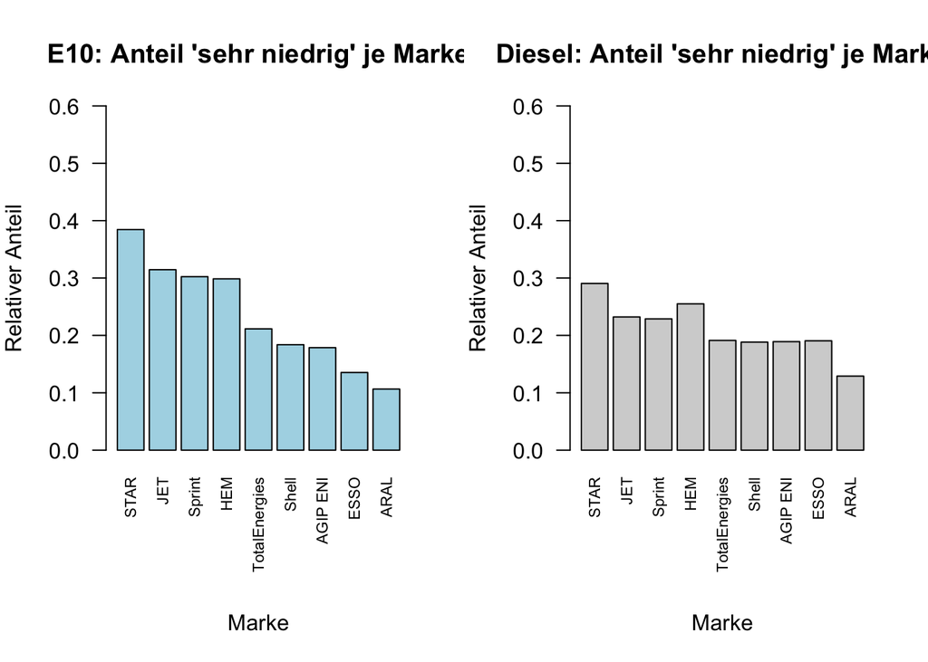

```r
# Anteil "sehr niedrig" pro Marke
sn_e10    <- rel_e10[,    "sehr niedrig"]
sn_diesel <- rel_diesel[, "sehr niedrig"]

# Nach E10-Anteil sortieren (absteigend, damit günstigste Marke zuerst)
ord2 <- order(sn_e10, decreasing = TRUE)
sn_e10    <- sn_e10[ord2]
sn_diesel <- sn_diesel[names(sn_e10)]

par(mfrow = c(1, 2), mar = c(8, 4, 4, 2))  # mar vergrößert unteren Rand

barplot(sn_e10,
        main      = "E10: Anteil 'sehr niedrig' je Marke",
        ylab      = "Relativer Anteil",
        col       = "lightblue",
        las       = 2,
        cex.names = 0.7,
        ylim      = c(0, 0.6))
mtext("Marke", side = 1, line = 6)  # xlab manuell tiefer setzen

barplot(sn_diesel,
        main      = "Diesel: Anteil 'sehr niedrig' je Marke",
        ylab      = "Relativer Anteil",
        col       = "lightgray",
        las       = 2,
        cex.names = 0.7,
        ylim      = c(0, 0.6))
mtext("Marke", side = 1, line = 6)  # xlab manuell tiefer setzen
```

```r
par(mfrow = c(1, 1), mar = c(5, 4, 4, 2))  # Ränder zurücksetzen auf Standard

data.frame(Marke = names(sn_e10),
           E10_sehr_niedrig    = round(sn_e10, 3),
           Diesel_sehr_niedrig = round(sn_diesel, 3))
```

```
##                       Marke E10_sehr_niedrig Diesel_sehr_niedrig
## STAR                   STAR            0.385               0.290
## JET                     JET            0.315               0.232
## Sprint               Sprint            0.302               0.229
## HEM                     HEM            0.299               0.255
## TotalEnergies TotalEnergies            0.211               0.191
## Shell                 Shell            0.184               0.188
## AGIP ENI           AGIP ENI            0.179               0.189
## ESSO                   ESSO            0.135               0.191
## ARAL                   ARAL            0.106               0.129
```

**c. Kontingenzmaß für den Zusammenhang von `brand` und Preiskategorie**

Als Kontingenzmaß verwenden wir Cramér’s V. Es basiert auf dem Chi-Quadrat-Wert der Kontingenztabelle und ist normiert auf den Bereich [0, 1], wobei 0 für keinen Zusammenhang und 1 für einen perfekten Zusammenhang steht. Das macht es gut vergleichbar, auch wenn die Tabellen unterschiedlich groß sind. Da wir sowohl `brand` (nominal) als auch die Preiskategorien (ordinal, aber als nominal behandelt) vorliegen haben, ist Cramér’s V hier passend. `chisq.test()` ist in Base R enthalten, für Cramér’s V rechnen wir die Formel selbst nach.

```r
# Chi-Quadrat-Tests
chi_e10    <- chisq.test(tab_e10)
chi_diesel <- chisq.test(tab_diesel)

# Cramér's V: sqrt( chi^2 / (n * (min(k, r) - 1)) )
n      <- nrow(tankerkoenig)
k_e10  <- min(nrow(tab_e10),    ncol(tab_e10))
k_die  <- min(nrow(tab_diesel), ncol(tab_diesel))

v_e10    <- sqrt(chi_e10$statistic    / (n * (k_e10 - 1)))
v_diesel <- sqrt(chi_diesel$statistic / (n * (k_die - 1)))

cat("Cramér's V  E10 ~ brand:    ", round(v_e10,    4), "\n")
```

```
## Cramér's V  E10 ~ brand:     0.1129
```

```r
cat("Cramér's V  Diesel ~ brand: ", round(v_diesel, 4), "\n")
```

```
## Cramér's V  Diesel ~ brand:  0.0795
```

Cramér’s V beträgt für E10 ca. 0.11 und für Diesel ca. 0.08. Diese Werte liegen unter 0.3 und deuten auf einen schwachen, aber vorhandenen Zusammenhang hin. Die Marke hat also einen messbaren, aber nicht sehr starken Einfluss auf die Preiskategorie.

**d. Erwartete absolute Häufigkeit von `(brand = SHELL, diesel_median_qualitativ = sehr hoch)` bei Unabhängigkeit**

Im Falle von Unabhängigkeit berechnet sich die erwartete absolute Häufigkeit einer Zelle als:

$$e_{ij} = \frac{n_{i \cdot} \cdot
n_{\cdot j}}{n}$$

Dabei ist $n_{i \cdot}$ die Zeilensumme (alle Shell-Beobachtungen), $n_{\cdot j}$ die Spaltensumme (alle Beobachtungen in *sehr hoch*) und $n$ die Gesamtzahl der Beobachtungen.

```r
# Markenname automatisch finden (enthält "shell", Groß-/Kleinschreibung egal)
shell_name  <- rownames(tab_diesel)[grep("shell", rownames(tab_diesel),
                                         ignore.case = TRUE)]

# as.numeric() verhindert den Integer Overflow
n_shell     <- as.numeric(sum(tab_diesel[shell_name, ]))
n_sehr_hoch <- as.numeric(sum(tab_diesel[, "sehr hoch"]))
n_gesamt    <- as.numeric(sum(tab_diesel))

e_shell_sehr_hoch <- (n_shell * n_sehr_hoch) / n_gesamt

cat("Markenname im Datensatz:            ", shell_name, "\n")
```

```
## Markenname im Datensatz:             Shell
```

```r
cat("Beobachtungen Shell gesamt:         ", n_shell, "\n")
```

```
## Beobachtungen Shell gesamt:          98465
```

```r
cat("Beobachtungen diesel 'sehr hoch':   ", n_sehr_hoch, "\n")
```

```
## Beobachtungen diesel 'sehr hoch':    85820
```

```r
cat("Gesamtbeobachtungen:                ", n_gesamt, "\n")
```

```
## Gesamtbeobachtungen:                 441078
```

```r
cat("Erwartete Häufigkeit (Unabh.):      ", round(e_shell_sehr_hoch, 2), "\n")
```

```
## Erwartete Häufigkeit (Unabh.):       19158.21
```

```r
cat("Tatsächliche Häufigkeit:            ", tab_diesel[shell_name, "sehr hoch"], "\n")
```

```
## Tatsächliche Häufigkeit:             21362
```

Die erwartete Häufigkeit gibt an, wie oft die Kombination *(SHELL, sehr hoch)* auftreten würde, wenn Marke und Preiskategorie völlig unabhängig voneinander wären – also wenn die Marke nichts über den Preis aussagen würde. Ist die tatsächliche Häufigkeit größer als die erwartete, heißt das, dass Shell öfter in der teuersten Kategorie landet als der Zufall es erklären könnte. Das wäre ein Hinweis darauf, dass Shell systematisch höhere Preise hat. Ist die tatsächliche Häufigkeit kleiner, wäre Shell günstiger als im Mittel erwartet.

## Woche 7 – 16.06.2026

Sie vertiefen diese Woche die Untersuchungen von Woche 4, in der Sie die Kraftstoffpreise `e10_median` und `diesel_median` über die Wochentage (a.), volle Stunden (b.) und die Marken (c.) aggregiert haben.

**a. Arithmetisches Mittel nach Wochentag und Streudiagramm**

Um zu sehen, ob E10 und Diesel an denselben Wochentagen teurer oder günstiger werden, berechnen wir für jeden der sieben Tage den Mittelwert beider Kraftstoffe mit `tapply()`. Die sieben Punkte tragen wir dann in ein Streudiagramm ein und beschriften sie mit dem Tageskürzel, damit sofort klar ist, welcher Punkt zu welchem Tag gehört. Den Pearson-Korrelationskoeffizienten berechnen wir anschließend mit `cor()`.

```r
# Arithmetische Mittel pro Wochentag
wt_mean_e10    <- tapply(tankerkoenig$e10_median,
                         tankerkoenig$wochentag, mean, na.rm = TRUE)
wt_mean_diesel <- tapply(tankerkoenig$diesel_median,
                         tankerkoenig$wochentag, mean, na.rm = TRUE)

# Pearson-Korrelation
r_wt <- cor(wt_mean_e10, wt_mean_diesel, method = "pearson")
cat("Pearson-Korrelation (Wochentag):", round(r_wt, 4), "\n")
```

```
## Pearson-Korrelation (Wochentag): 0.6073
```

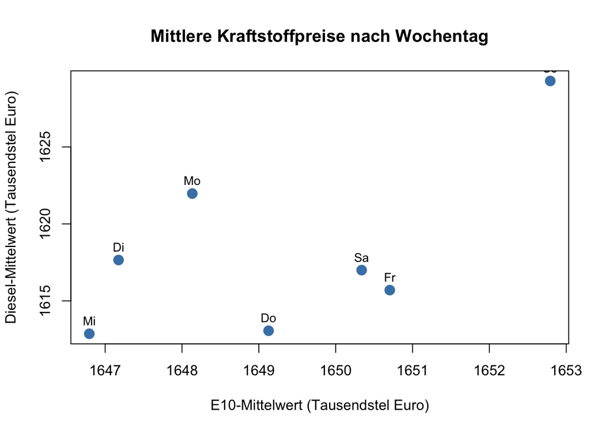

```r
# Streudiagramm
plot(wt_mean_e10, wt_mean_diesel,
     main = "Mittlere Kraftstoffpreise nach Wochentag",
     xlab = "E10-Mittelwert (Tausendstel Euro)",
     ylab = "Diesel-Mittelwert (Tausendstel Euro)",
     pch  = 19, col = "steelblue", cex = 1.5)

# Wochentag-Kürzel als Punktbeschriftung
text(wt_mean_e10, wt_mean_diesel,
     labels = c("Mo", "Di", "Mi", "Do", "Fr", "Sa", "So"),
     pos = 3, cex = 0.85)
```

**b. Arithmetisches Mittel nach Uhrzeit und Streudiagramm**

```r
# Arithmetische Mittel pro Stunde
uh_mean_e10    <- tapply(tankerkoenig$e10_median,
                         tankerkoenig$time_f, mean, na.rm = TRUE)
uh_mean_diesel <- tapply(tankerkoenig$diesel_median,
                         tankerkoenig$time_f, mean, na.rm = TRUE)

# Pearson-Korrelation
r_uh <- cor(uh_mean_e10, uh_mean_diesel, method = "pearson")
cat("Pearson-Korrelation (Uhrzeit):", round(r_uh, 4), "\n")
```

```
## Pearson-Korrelation (Uhrzeit): 0.9588
```

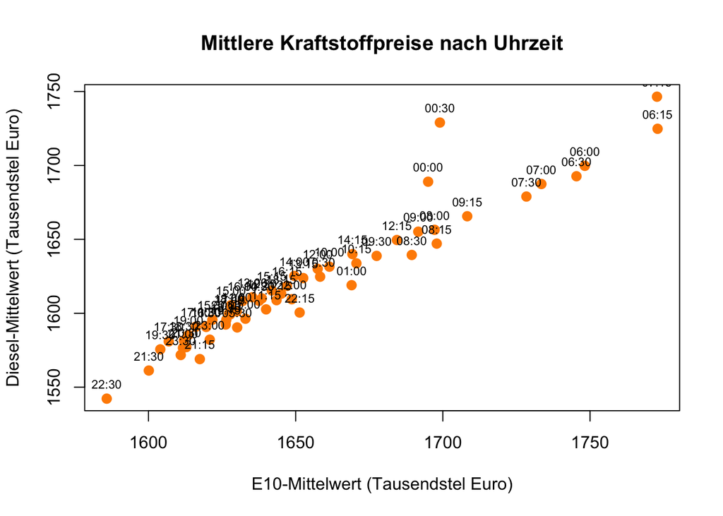

```r
# Streudiagramm
plot(uh_mean_e10, uh_mean_diesel,
     main = "Mittlere Kraftstoffpreise nach Uhrzeit",
     xlab = "E10-Mittelwert (Tausendstel Euro)",
     ylab = "Diesel-Mittelwert (Tausendstel Euro)",
     pch  = 19, col = "darkorange", cex = 1.2)

# Stunden als Punktbeschriftung
text(uh_mean_e10, uh_mean_diesel,
     labels = names(uh_mean_e10),
     pos = 3, cex = 0.7)
```

**c. Arithmetisches Mittel nach Marke und Streudiagramm**

Wir wollen wissen, ob Marken, die bei E10 teuer sind, das auch bei Diesel sind. Dazu berechnen wir für jede Marke den Mittelwert beider Kraftstoffe und tragen jeden Markenmittelwert als Punkt ins Streudiagramm ein. Da es keine sinnvolle Reihenfolge unter den Marken gibt, beschriften wir die Punkte direkt mit den Markennamen.

```r
# Arithmetische Mittel pro Marke
mk_mean_e10    <- tapply(tankerkoenig$e10_median,
                         tankerkoenig$brand, mean, na.rm = TRUE)
mk_mean_diesel <- tapply(tankerkoenig$diesel_median,
                         tankerkoenig$brand, mean, na.rm = TRUE)

# Pearson-Korrelation
r_mk <- cor(mk_mean_e10, mk_mean_diesel, method = "pearson")
cat("Pearson-Korrelation (Marke):", round(r_mk, 4), "\n")
```

```
## Pearson-Korrelation (Marke): 0.9851
```

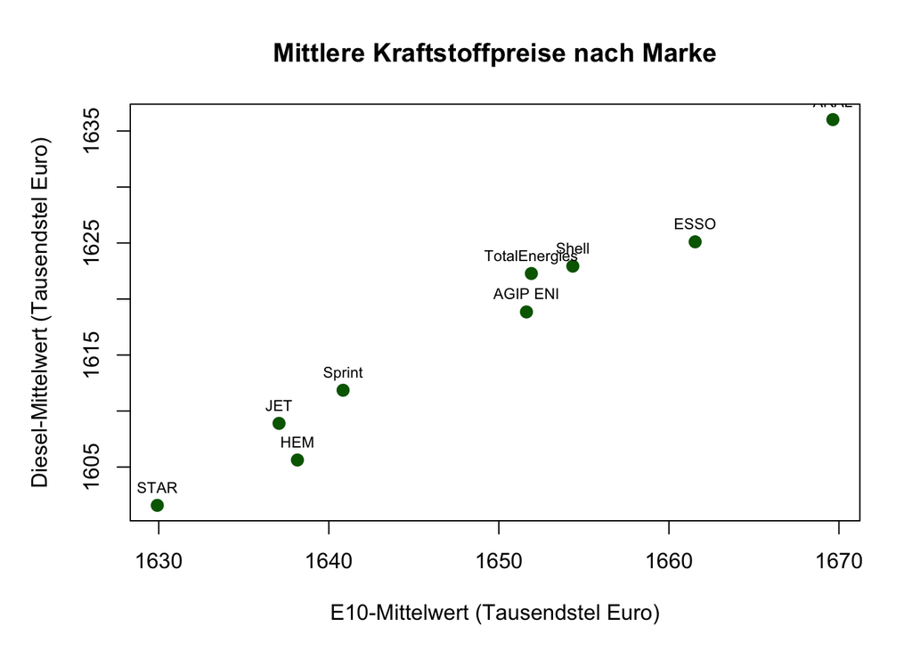

```r
# Streudiagramm
par(mar = c(5, 5, 4, 2))
plot(mk_mean_e10, mk_mean_diesel,
     main = "Mittlere Kraftstoffpreise nach Marke",
     xlab = "E10-Mittelwert (Tausendstel Euro)",
     ylab = "Diesel-Mittelwert (Tausendstel Euro)",
     pch  = 19, col = "darkgreen", cex = 1.2)

# Markennamen als Punktbeschriftung
text(mk_mean_e10, mk_mean_diesel,
     labels = names(mk_mean_e10),
     pos = 3, cex = 0.7)
```

```r
par(mar = c(5, 4, 4, 2))
```

**d. Streudiagramm und Pearson-Korrelation im Originaldatensatz**

Zum Vergleich schauen wir uns jetzt alle Einzelbeobachtungen auf einmal an, also ohne jede Aggregierung. Da es sich um sehr viele Datenpunkte handelt, wäre ein normales Streudiagramm ein einziger schwarzer Fleck. Deshalb setzen wir die Punkte sehr transparent (`alpha = 0.05`), sodass Bereiche mit vielen übereinanderliegenden Punkten dunkler erscheinen als dünn besetzte Bereiche.

```r
# Nur vollständige Paare verwenden (kein NA in e10 oder diesel)
komplett <- !is.na(tankerkoenig$e10_median) & !is.na(tankerkoenig$diesel_median)
e10_komplett    <- tankerkoenig$e10_median[komplett]
diesel_komplett <- tankerkoenig$diesel_median[komplett]

# Pearson-Korrelation
r_orig <- cor(e10_komplett, diesel_komplett, method = "pearson")
cat("Pearson-Korrelation (Originaldatensatz):", round(r_orig, 4), "\n")
```

```
## Pearson-Korrelation (Originaldatensatz): 0.7755
```

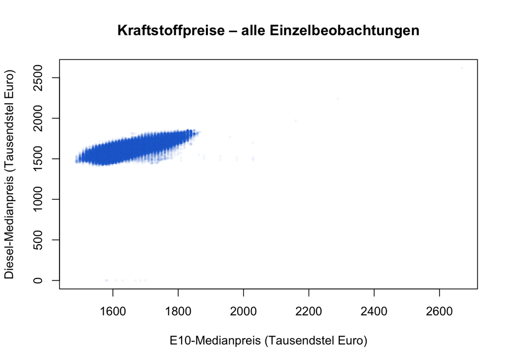

```r
# Streudiagramm mit starker Transparenz wegen Überlappung
plot(e10_komplett, diesel_komplett,
     main = "Kraftstoffpreise – alle Einzelbeobachtungen",
     xlab = "E10-Medianpreis (Tausendstel Euro)",
     ylab = "Diesel-Medianpreis (Tausendstel Euro)",
     pch  = 16,
     col  = rgb(0.1, 0.4, 0.8, 0.05),
     cex  = 0.5)
```

**e. Vergleich der Streudiagramme und Korrelationen (a bis d)**

Um die vier Ergebnisse direkt vergleichen zu können, fassen wir die Korrelationswerte in einer Tabelle zusammen.

```r
data.frame(
  Aggregierung  = c("Wochentag (7 Punkte)",
                    "Uhrzeit (24 Punkte)",
                    "Marke (je 1 Punkt pro Marke)",
                    "Originaldaten (alle Einzelwerte)"),
  Pearson_r     = round(c(r_wt, r_uh, r_mk, r_orig), 4)
)
```

```
##                       Aggregierung Pearson_r
## 1             Wochentag (7 Punkte)    0.6073
## 2              Uhrzeit (24 Punkte)    0.9588
## 3     Marke (je 1 Punkt pro Marke)    0.9851
## 4 Originaldaten (alle Einzelwerte)    0.7755
```

Das zeigt auch ein wichtiges statistisches Prinzip: Eine hohe Korrelation auf aggregierter Ebene bedeutet nicht automatisch, dass derselbe starke Zusammenhang auch für jede einzelne Beobachtung gilt. Wer das übersieht und von den aggregierten Werten auf die Einzelwerte schließt, begeht den sogenannten **ökologischen Fehlschluss** (*ecological fallacy*).

## Woche 8 – 23.06.2026

**a. Lineare Regression: `diesel_median` ~ `e10_median`**

Wir wollen wissen, wie gut sich der Dieselpreis aus dem E10-Preis vorhersagen lässt. Dazu berechnen wir eine einfache lineare Regression mit `lm()`. Die Koeffizienten `a` (Steigung) und `b` (Achsenabschnitt) entnehmen wir direkt aus dem Modell und setzen sie in die Geradengleichung ein. Die `summary()` gibt uns außerdem das Bestimmtheitsmaß R² und weitere Gütemaße, die wir wie in der Vorlesung besprochen interpretieren.

```r
# Monatsspalte erstellen (wird für Aufgabe d benötigt)
tankerkoenig$monat <- as.integer(format(as.Date(tankerkoenig$date), "%m"))
tankerkoenig$monat_f <- factor(tankerkoenig$monat,
                                levels = 1:12,
                                labels = c("Jan","Feb","Mar","Apr","Mai","Jun",
                                           "Jul","Aug","Sep","Okt","Nov","Dez"))

# Einfache lineare Regression
modell_1 <- lm(diesel_median ~ e10_median, data = tankerkoenig)

# Koeffizienten auslesen
a <- round(coef(modell_1)["e10_median"], 4)
b <- round(coef(modell_1)["(Intercept)"], 4)

cat("Geradengleichung:\n")
```

```
## Geradengleichung:
```

```r
cat("diesel_median =", a, "x e10_median +", b, "\n\n")
```

```
## diesel_median = 0.8394 x e10_median + 233.7446
```

```r
# Summary des Modells
summary(modell_1)
```

```
##
## Call:
## lm(formula = diesel_median ~ e10_median, data = tankerkoenig)
##
## Residuals:
##      Min       1Q   Median       3Q      Max
## -1659.86   -25.32     2.35    26.65   192.71
##
## Coefficients:
##              Estimate Std. Error t value Pr(>|t|)
## (Intercept) 233.74455    1.69971   137.5   <2e-16 ***
## e10_median    0.83939    0.00103   815.0   <2e-16 ***
## ---
## Signif. codes:  0 '***' 0.001 '**' 0.01 '*' 0.05 '.' 0.1 ' ' 1
##
## Residual standard error: 40.63 on 440265 degrees of freedom
##   (811 observations deleted due to missingness)
## Multiple R-squared:  0.6014, Adjusted R-squared:  0.6014
## F-statistic: 6.642e+05 on 1 and 440265 DF,  p-value: < 2.2e-16
```

Die Geradengleichung lautet: **diesel_median = 0.8394 × e10_median + 233.7446**

Das bedeutet: Steigt der E10-Preis um eine Einheit (also um 0,001 Euro), steigt der Dieselpreis im Schnitt um den Faktor `a`. Der Achsenabschnitt `b` wäre der theoretische Dieselpreis, wenn E10 den Preis 0 hätte – das ist in der Praxis nicht sinnvoll interpretierbar, sondern nur ein mathematischer Ausgangspunkt der Geraden.

Aus der `summary()` lesen wir folgende Werte ab:

- **Koeffizienten**: Beide Koeffizienten (`(Intercept)` und `e10_median`) sind hochsignifikant (p < 2e-16, markiert mit `***`). Das bedeutet, der Zusammenhang ist statistisch klar nachweisbar.
- **Residual standard error**: Gibt die typische Abweichung der tatsächlichen Dieselpreise von der Regressionsgerade an (in Tausendstel Euro).
- **R²** (Multiple R-squared): Gibt an, wie viel Prozent der Gesamtstreuung von `diesel_median` durch `e10_median` erklärt werden. Ein R² von z.B. 0.50 würde bedeuten, dass 50% der Variation im Dieselpreis allein durch den E10-Preis erklärt werden.
- **Adjusted R²**: Korrigiert R² um die Anzahl der Prädiktoren – bei einem Prädiktor kaum ein Unterschied zu R².

Das Modell erklärt einen nennenswerten Teil der Variation, ist aber kein perfektes Modell, weil viele Einzelbeobachtungen stark von der Geraden abweichen (große Residuen). Das war bereits im Streudiagramm aus Aufgabe 7d zu sehen.

**b. Streudiagramm mit Regressionsgerade**

Wir zeichnen alle Einzelbeobachtungen als Punktwolke und legen die Regressionsgerade mit `abline()` darüber. Wegen der sehr großen Datenmenge setzen wir die Punkte wieder transparent.

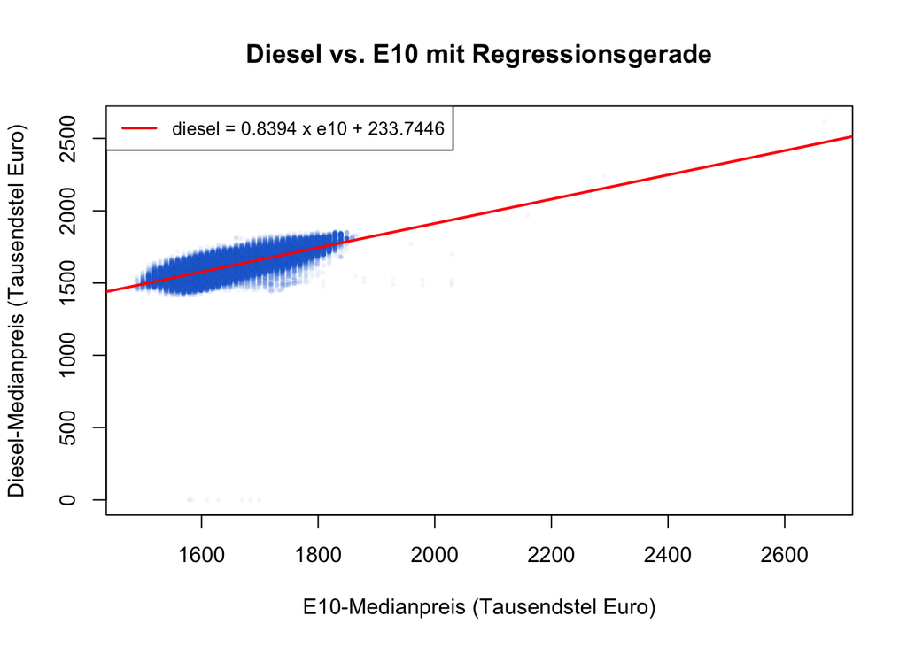

```r
# Vollständige Paare
komplett <- !is.na(tankerkoenig$e10_median) & !is.na(tankerkoenig$diesel_median)

# Streudiagramm
plot(tankerkoenig$e10_median[komplett],
     tankerkoenig$diesel_median[komplett],
     main = "Diesel vs. E10 mit Regressionsgerade",
     xlab = "E10-Medianpreis (Tausendstel Euro)",
     ylab = "Diesel-Medianpreis (Tausendstel Euro)",
     pch  = 16,
     col  = rgb(0.1, 0.4, 0.8, 0.05),
     cex  = 0.5)

# Regressionsgerade hinzufügen
abline(modell_1, col = "red", lwd = 2)

# Legende
legend("topleft",
       legend = paste0("diesel = ", a, " x e10 + ", b),
       col = "red", lwd = 2, cex = 0.85)
```

Die Regressionsgerade verläuft durch die Mitte der Punktwolke und zeigt den positiven linearen Trend deutlich: Je höher der E10-Preis, desto höher auch der Dieselpreis. Allerdings ist die Streuung der Punkte um die Gerade beachtlich – viele Beobachtungen liegen weit von der Geraden entfernt. Das deutet darauf hin, dass `e10_median` allein nicht ausreicht, um `diesel_median` präzise vorherzusagen. Es gibt offensichtlich weitere Einflussfaktoren wie Marke, Tageszeit oder Monat, die die Punktwolke verbreitern.

**c. Streudiagramm: tatsächliche vs. geschätzte Werte**

Um zu sehen, wie gut das Modell die einzelnen Beobachtungen trifft, vergleichen wir die tatsächlichen Dieselpreise (`diesel_median`) mit den vom Modell geschätzten Werten (`fitted.values`). Bei einem perfekten Modell würden alle Punkte exakt auf der Linie y = x liegen.

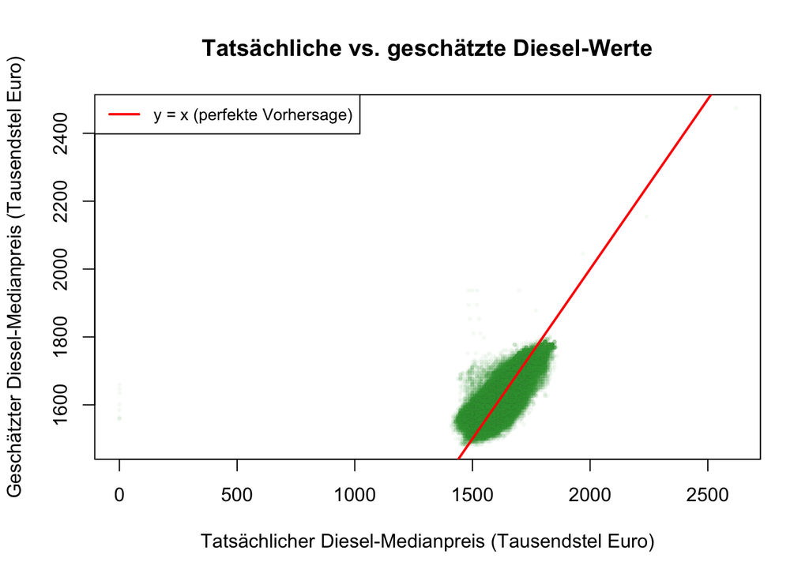

```r
# Gefittete Werte
diesel_fitted <- fitted(modell_1)
diesel_actual <- tankerkoenig$diesel_median[!is.na(tankerkoenig$e10_median) &
                                             !is.na(tankerkoenig$diesel_median)]

# Streudiagramm tatsächlich vs. geschätzt
plot(diesel_actual, diesel_fitted,
     main = "Tatsächliche vs. geschätzte Diesel-Werte",
     xlab = "Tatsächlicher Diesel-Medianpreis (Tausendstel Euro)",
     ylab = "Geschätzter Diesel-Medianpreis (Tausendstel Euro)",
     pch  = 16,
     col  = rgb(0.2, 0.6, 0.2, 0.05),
     cex  = 0.5)

# y = x Linie (perfekte Vorhersage)
abline(a = 0, b = 1, col = "red", lwd = 2)

legend("topleft", legend = "y = x (perfekte Vorhersage)",
       col = "red", lwd = 2, cex = 0.85)
```

Wenn das Modell perfekt wäre, würden alle Punkte auf der roten Linie y = x liegen. In der Realität sehen wir eine breite Punktwolke um diese Linie. Die geschätzten Werte variieren deutlich weniger als die tatsächlichen – die Wolke ist in der Vertikale schmaler als in der Horizontale. Das ist typisch für ein einfaches Regressionsmodell mit einem Prädiktor: Es erfasst den mittleren Trend, glättet aber die extremen Werte nach innen. Sehr hohe oder sehr niedrige tatsächliche Preise werden vom Modell systematisch unterschätzt bzw. überschätzt.

**d. Multivariate lineare Regressionsmodelle**

Wir erweitern das Modell aus Aufgabe a schrittweise um weitere Prädiktoren. Monat und Marke sind kategoriale Variablen – R erstellt daraus automatisch Dummy-Variablen. Das Modell mit allen drei Prädiktoren kombiniert alle Informationen.

```r
# Modell 2: e10_median + Monat
modell_2 <- lm(diesel_median ~ e10_median + monat_f, data = tankerkoenig)

# Modell 3: e10_median + Marke
modell_3 <- lm(diesel_median ~ e10_median + brand, data = tankerkoenig)

# Modell 4: e10_median + Monat + Marke
modell_4 <- lm(diesel_median ~ e10_median + monat_f + brand, data = tankerkoenig)

# Summaries
cat("=== Modell 2: e10_median + Monat ===\n")
```

```
## === Modell 2: e10_median + Monat ===
```

```r
summary(modell_2)
```

```
##
## Call:
## lm(formula = diesel_median ~ e10_median + monat_f, data = tankerkoenig)
##
## Residuals:
##      Min       1Q   Median       3Q      Max
## -1654.46   -21.28    -1.23    19.96   184.21
##
## Coefficients:
##               Estimate Std. Error t value Pr(>|t|)
## (Intercept)  3.273e+02  1.680e+00  194.79   <2e-16 ***
## e10_median   8.063e-01  9.842e-04  819.25   <2e-16 ***
## monat_fFeb  -3.850e+01  2.464e-01 -156.23   <2e-16 ***
## monat_fMar  -3.793e+01  2.404e-01 -157.78   <2e-16 ***
## monat_fApr  -6.598e+01  2.471e-01 -267.02   <2e-16 ***
## monat_fMai  -8.146e+01  2.500e-01 -325.77   <2e-16 ***
## monat_fJun  -7.790e+01  2.462e-01 -316.48   <2e-16 ***
## monat_fJul  -2.912e+01  2.468e-01 -117.98   <2e-16 ***
## monat_fAug  -4.272e+01  2.475e-01 -172.62   <2e-16 ***
## monat_fSep  -2.443e+01  2.483e-01  -98.39   <2e-16 ***
## monat_fOkt  -3.859e+01  2.458e-01 -157.01   <2e-16 ***
## monat_fNov  -1.356e+01  2.488e-01  -54.51   <2e-16 ***
## monat_fDez  -1.915e+01  2.607e-01  -73.43   <2e-16 ***
## ---
## Signif. codes:  0 '***' 0.001 '**' 0.01 '*' 0.05 '.' 0.1 ' ' 1
##
## Residual standard error: 32.77 on 440254 degrees of freedom
##   (811 observations deleted due to missingness)
## Multiple R-squared:  0.7406, Adjusted R-squared:  0.7406
## F-statistic: 1.048e+05 on 12 and 440254 DF,  p-value: < 2.2e-16
```

```r
cat("=== Modell 3: e10_median + Marke ===\n")
```

```
## === Modell 3: e10_median + Marke ===
```

```r
summary(modell_3)
```

```
##
## Call:
## lm(formula = diesel_median ~ e10_median + brand, data = tankerkoenig)
##
## Residuals:
##      Min       1Q   Median       3Q      Max
## -1659.51   -25.21     2.21    26.75   193.03
##
## Coefficients:
##                      Estimate Std. Error t value Pr(>|t|)
## (Intercept)        233.926568   1.751539 133.555  < 2e-16 ***
## e10_median           0.838520   0.001051 798.185  < 2e-16 ***
## brandARAL            2.066158   0.296584   6.967 3.25e-12 ***
## brandESSO           -2.058094   0.338277  -6.084 1.17e-09 ***
## brandHEM            -1.924047   0.311739  -6.172 6.75e-10 ***
## brandJET             2.253954   0.324731   6.941 3.90e-12 ***
## brandShell           1.688882   0.272494   6.198 5.73e-10 ***
## brandSprint          2.054875   0.325519   6.313 2.75e-10 ***
## brandSTAR            0.935448   0.297852   3.141  0.00169 **
## brandTotalEnergies   3.191820   0.286347  11.147  < 2e-16 ***
## ---
## Signif. codes:  0 '***' 0.001 '**' 0.01 '*' 0.05 '.' 0.1 ' ' 1
##
## Residual standard error: 40.6 on 440257 degrees of freedom
##   (811 observations deleted due to missingness)
## Multiple R-squared:  0.602,  Adjusted R-squared:  0.602
## F-statistic: 7.4e+04 on 9 and 440257 DF,  p-value: < 2.2e-16
```

```r
cat("=== Modell 4: e10_median + Monat + Marke ===\n")
```

```
## === Modell 4: e10_median + Monat + Marke ===
```

```r
summary(modell_4)
```

```
##
## Call:
## lm(formula = diesel_median ~ e10_median + monat_f + brand, data = tankerkoenig)
##
## Residuals:
##      Min       1Q   Median       3Q      Max
## -1653.40   -21.20    -1.21    20.04   184.86
##
## Coefficients:
##                      Estimate Std. Error  t value Pr(>|t|)
## (Intercept)        332.524073   1.739518  191.159  < 2e-16 ***
## e10_median           0.802658   0.001012  793.367  < 2e-16 ***
## monat_fFeb         -38.400903   0.246183 -155.985  < 2e-16 ***
## monat_fMar         -37.988100   0.240152 -158.183  < 2e-16 ***
## monat_fApr         -66.166644   0.247164 -267.703  < 2e-16 ***
## monat_fMai         -81.703445   0.250382 -326.315  < 2e-16 ***
## monat_fJun         -78.042101   0.246123 -317.085  < 2e-16 ***
## monat_fJul         -29.286784   0.246947 -118.596  < 2e-16 ***
## monat_fAug         -42.892322   0.247627 -173.213  < 2e-16 ***
## monat_fSep         -24.623687   0.248333  -99.156  < 2e-16 ***
## monat_fOkt         -38.784223   0.245876 -157.739  < 2e-16 ***
## monat_fNov         -13.786312   0.248969  -55.374  < 2e-16 ***
## monat_fDez         -19.535294   0.261625  -74.669  < 2e-16 ***
## brandARAL            2.668094   0.239336   11.148  < 2e-16 ***
## brandESSO           -1.473581   0.272808   -5.402 6.61e-08 ***
## brandHEM            -2.632643   0.251498  -10.468  < 2e-16 ***
## brandJET             1.542658   0.261951    5.889 3.89e-09 ***
## brandShell           1.576098   0.219723    7.173 7.34e-13 ***
## brandSprint          0.794029   0.262548    3.024  0.00249 **
## brandSTAR            0.049386   0.240459    0.205  0.83727
## brandTotalEnergies   2.651609   0.230903   11.484  < 2e-16 ***
## ---
## Signif. codes:  0 '***' 0.001 '**' 0.01 '*' 0.05 '.' 0.1 ' ' 1
##
## Residual standard error: 32.73 on 440246 degrees of freedom
##   (811 observations deleted due to missingness)
## Multiple R-squared:  0.7413, Adjusted R-squared:  0.7413
## F-statistic: 6.306e+04 on 20 and 440246 DF,  p-value: < 2.2e-16
```

```r
# Übersichtstabelle der R²-Werte
r2_tabelle <- data.frame(
  Modell        = c("Modell 1: nur e10_median",
                    "Modell 2: e10_median + Monat",
                    "Modell 3: e10_median + Marke",
                    "Modell 4: e10_median + Monat + Marke"),
  R2            = round(c(summary(modell_1)$r.squared,
                          summary(modell_2)$r.squared,
                          summary(modell_3)$r.squared,
                          summary(modell_4)$r.squared), 4),
  Adj_R2        = round(c(summary(modell_1)$adj.r.squared,
                          summary(modell_2)$adj.r.squared,
                          summary(modell_3)$adj.r.squared,
                          summary(modell_4)$adj.r.squared), 4),
  Residual_SE   = round(c(summary(modell_1)$sigma,
                          summary(modell_2)$sigma,
                          summary(modell_3)$sigma,
                          summary(modell_4)$sigma), 2)
)
r2_tabelle
```

```
##                                 Modell     R2 Adj_R2 Residual_SE
## 1             Modell 1: nur e10_median 0.6014 0.6014       40.63
## 2         Modell 2: e10_median + Monat 0.7406 0.7406       32.77
## 3         Modell 3: e10_median + Marke 0.6020 0.6020       40.60
## 4 Modell 4: e10_median + Monat + Marke 0.7413 0.7413       32.73
```

Anhand von R², Adjusted R² und dem Residual Standard Error lässt sich die Modellgüte direkt vergleichen:

**Bestes Modell – Modell 4 (e10_median + Monat + Marke):** Dieses Modell hat das höchste R² und das niedrigste Residual Standard Error. Es nutzt alle verfügbaren Informationen: den Zusammenhang mit dem E10-Preis, saisonale Schwankungen durch den Monat und markenspezifische Preisstrategien. Dadurch kann es die Streuung des Dieselpreises am besten erklären.

**Zweitbestes Modell – Modell 2 (e10_median + Monat):** Der Monat erklärt mit R² = 0.74 deutlich mehr als die Marke allein, weil saisonale Preisschwankungen (z.B. Sommer vs. Winter) einen starken Einfluss auf den Dieselpreis haben.

**Drittbestes Modell – Modell 3 (e10_median + Marke):** Die Marke verbessert R² gegenüber Modell 1 nur minimal (0.60 vs. 0.60), weil der Markeneffekt schon teilweise im E10-Preis enthalten ist.

**Schlechtestes Modell – Modell 1 (nur e10_median):** Das einfachste Modell erklärt am wenigsten Variation. Es ist ein sinnvoller Ausgangspunkt, aber ohne weitere Prädiktoren bleibt viel Streuung unerklärbar.

## Woche 9 – 30.06.2026

**a. Erklärung des Codeblocks und Liniendiagramm**

Der obige Codeblock bereitet die Rohdaten einer einzelnen Tankstelle für eine Zeitreihenanalyse vor. Er tut das in mehreren Schritten:

1. **Filtern:** Zunächst werden nur die Zeilen der Tankstelle mit der angegebenen `id` aus dem Gesamtdatensatz `tankerkoenig` extrahiert. Behalten werden nur Datum, Uhrzeit und die beiden Preisspalten.
2. **Stunde ableiten:** Aus dem Zeitstring (z.B. `"05:00"`) wird die Stunde als Ganzzahl extrahiert (z.B. `5`), um damit später rechnen zu können.
3. **Fehlende Stunden auffüllen (`fill_hours`):** Für jeden Tag wird geprüft, ob alle Stunden von 5 bis 23 vorhanden sind. Fehlt eine Stunde, wird eine neue Zeile eingefügt – mit `NA` als Preiswert. So hat jeder Tag exakt 19 Zeilen (eine pro Stunde von 5 bis 23 Uhr).
4. **Fehlende Preise imputieren (`impute_col`, `impute_group`):** Die `NA`-Werte werden durch sogenanntes *Forward-Fill* und *Backward-Fill* ersetzt: Für 5 Uhr wird der nächste bekannte Wert nach vorne gesucht, für alle anderen Stunden der letzte bekannte Wert davor. Damit entstehen keine Lücken in der Zeitreihe.
5. **Aggregieren:** Schließlich wird pro Datum und Stunde der Median der Preise berechnet. Jede Stunde eines Tages hat damit genau einen Wert. Ein fortlaufender Index `index` wird ergänzt, damit die Zeitreihe als Sequenz dargestellt werden kann.

```r
library(dplyr)
```

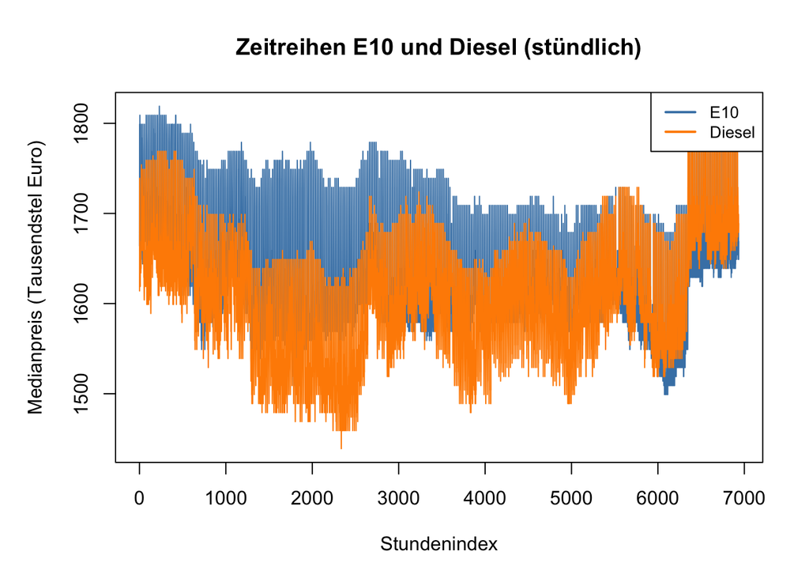

```r
df <- tankerkoenig[tankerkoenig$id == "005056ba-7cb6-1ee5-b187-bc79c0a8d9ec",
                   c("date", "time", "e10_median", "diesel_median")]

df$hour <- as.integer(sub(":.*", "", df$time))

hours_full <- 5:23
price_cols <- c("e10_median", "diesel_median")

fill_hours <- function(rows) {
  missing_hours <- setdiff(hours_full, rows$hour)
  if (length(missing_hours) == 0) return(rows)
  new_rows <- rows[rep(1, length(missing_hours)), ]
  rownames(new_rows) <- NULL
  new_rows$time        <- sprintf("%02d:00", missing_hours)
  new_rows$hour        <- missing_hours
  new_rows[price_cols] <- NA
  bind_rows(rows, new_rows)
}

impute_col <- function(values, hours) {
  out <- values
  for (i in seq_along(out)) {
    if (!is.na(out[i])) next
    if (hours[i] == 5) {
      candidates <- which(!is.na(out) & hours > hours[i])
      if (length(candidates) > 0)
        out[i] <- out[candidates[which.min(hours[candidates])]]
    } else {
      candidates <- which(!is.na(out) & hours < hours[i] & hours >= 5)
      if (length(candidates) > 0)
        out[i] <- out[candidates[which.max(hours[candidates])]]
    }
  }
  out
}

impute_group <- function(rows) {
  rows <- rows[order(rows$hour), ]
  for (col in price_cols) rows[[col]] <- impute_col(rows[[col]], rows$hour)
  rows
}

df_out <- df %>%
  group_by(date) %>%
  group_modify(~ fill_hours(.x)) %>%
  group_modify(~ impute_group(.x)) %>%
  ungroup() %>%
  arrange(date, hour) %>%
  select(-hour)

price_medianByHour <- df_out |>
  group_by(date, hour = substr(time, 1, 2)) |>
  summarise(e10_median    = median(e10_median,    na.rm = TRUE),
            diesel_median = median(diesel_median, na.rm = TRUE),
            .groups = "drop")
price_medianByHour$index <- seq_len(nrow(price_medianByHour))

# Liniendiagramm beider Zeitreihen
par(mar = c(5, 5, 4, 2))
plot(price_medianByHour$index, price_medianByHour$e10_median,
     type = "l", col = "steelblue", lwd = 1,
     main = "Zeitreihen E10 und Diesel (stündlich)",
     xlab = "Stundenindex",
     ylab = "Medianpreis (Tausendstel Euro)",
     ylim = range(c(price_medianByHour$e10_median,
                    price_medianByHour$diesel_median), na.rm = TRUE))
lines(price_medianByHour$index, price_medianByHour$diesel_median,
      col = "darkorange", lwd = 1)
legend("topright",
       legend = c("E10", "Diesel"),
       col    = c("steelblue", "darkorange"),
       lwd    = 2, cex = 0.85)
```

**b. Glättung mit gleitendem Mittelwert**

Ein zentrierter gleitender Mittelwert über 73 Punkte entspricht genau 73 aufeinanderfolgenden Stundenwerten. Da wir 19 Stunden pro Tag haben, entspricht das ungefähr 3,8 Tagen – damit werden die täglichen Schwankungen vollständig herausgemittelt und nur der mittelfristige Trend bleibt sichtbar.

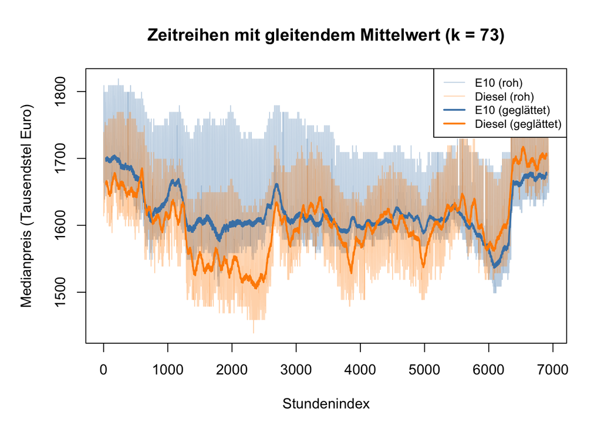

```r
# Hilfsfunktion: zentrierter gleitender Mittelwert
moving_avg <- function(x, k) {
  n    <- length(x)
  half <- (k - 1) / 2
  out  <- rep(NA, n)
  for (i in seq_len(n)) {
    lo <- i - half
    hi <- i + half
    if (lo >= 1 && hi <= n) {
      out[i] <- mean(x[lo:hi], na.rm = TRUE)
    }
  }
  out
}

price_medianByHour$e10_smooth    <- moving_avg(price_medianByHour$e10_median,    73)
price_medianByHour$diesel_smooth <- moving_avg(price_medianByHour$diesel_median, 73)

# Liniendiagramm mit Glättung
par(mar = c(5, 5, 4, 2))
plot(price_medianByHour$index, price_medianByHour$e10_median,
     type = "l", col = adjustcolor("steelblue", 0.35), lwd = 1,
     main = "Zeitreihen mit gleitendem Mittelwert (k = 73)",
     xlab = "Stundenindex",
     ylab = "Medianpreis (Tausendstel Euro)",
     ylim = range(c(price_medianByHour$e10_median,
                    price_medianByHour$diesel_median), na.rm = TRUE))
lines(price_medianByHour$index, price_medianByHour$diesel_median,
      col = adjustcolor("darkorange", 0.35), lwd = 1)
lines(price_medianByHour$index, price_medianByHour$e10_smooth,
      col = "steelblue", lwd = 2)
lines(price_medianByHour$index, price_medianByHour$diesel_smooth,
      col = "darkorange", lwd = 2)
legend("topright",
       legend = c("E10 (roh)", "Diesel (roh)",
                  "E10 (geglättet)", "Diesel (geglättet)"),
       col    = c(adjustcolor("steelblue", 0.35),
                  adjustcolor("darkorange", 0.35),
                  "steelblue", "darkorange"),
       lwd    = c(1, 1, 2, 2), cex = 0.8)
```

**c. Differenzzeitreihe und Autokorrelation**

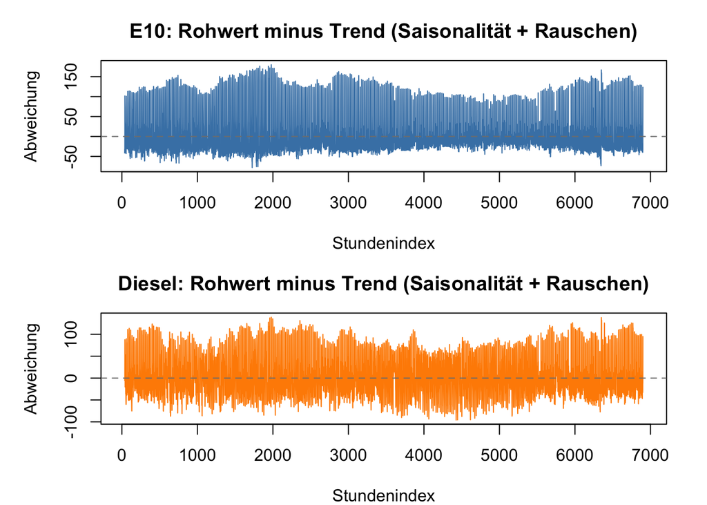

```r
e10_median_diff    <- price_medianByHour$e10_median    - price_medianByHour$e10_smooth
diesel_median_diff <- price_medianByHour$diesel_median - price_medianByHour$diesel_smooth

# Liniendiagramm der Differenzzeitreihen
par(mfrow = c(2, 1), mar = c(4, 5, 3, 2))

plot(price_medianByHour$index, e10_median_diff,
     type = "l", col = "steelblue", lwd = 1,
     main = "E10: Rohwert minus Trend (Saisonalität + Rauschen)",
     xlab = "Stundenindex", ylab = "Abweichung")
abline(h = 0, lty = 2, col = "gray50")

plot(price_medianByHour$index, diesel_median_diff,
     type = "l", col = "darkorange", lwd = 1,
     main = "Diesel: Rohwert minus Trend (Saisonalität + Rauschen)",
     xlab = "Stundenindex", ylab = "Abweichung")
abline(h = 0, lty = 2, col = "gray50")
```

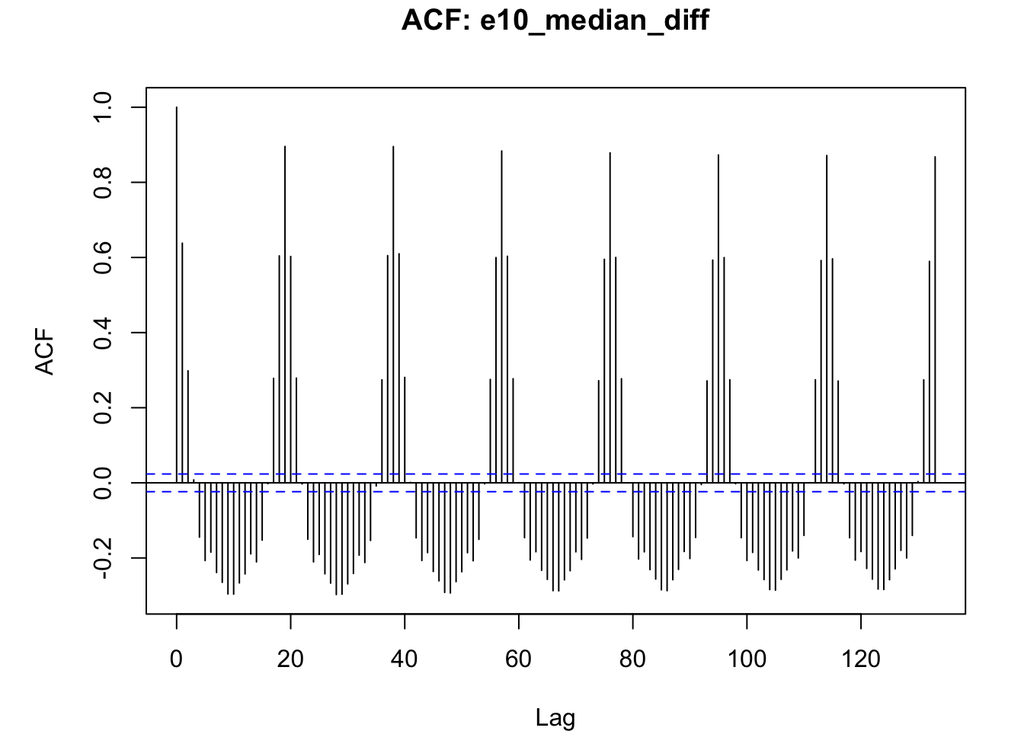

```r
par(mfrow = c(1, 1))

# Autokorrelation
acf(e10_median_diff,    lag.max = 133, na.action = na.pass,
    main = "ACF: e10_median_diff")
```

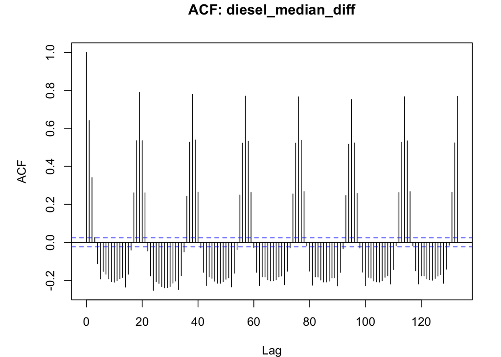

```r
acf(diesel_median_diff, lag.max = 133, na.action = na.pass,
    main = "ACF: diesel_median_diff")
```

Die Differenzzeitreihen zeigen, was nach dem Abziehen des Trends übrig bleibt: die **Saisonalität** (tägliche Schwankungen) und das **Rauschen**. Im Liniendiagramm ist ein klares, regelmäßiges Muster erkennbar – die Preise schwingen täglich um den Trend, mit einem typischen Tief mittags und einem Hoch morgens. Das entspricht genau dem, was wir in Aufgabe 4b für alle Tankstellen gemeinsam beobachtet haben: der Tagesrhythmus ist auch für diese einzelne Tankstelle sehr deutlich ausgeprägt.

Die Funktion `acf()` berechnet die **Autokorrelationsfunktion** (ACF). Sie misst, wie stark ein Wert der Zeitreihe mit dem Wert korreliert, der `k` Schritte früher liegt. Für Lag 0 ist die Korrelation immer 1 (ein Wert korreliert perfekt mit sich selbst). Für größere Lags zeigt die ACF, ob und wie stark Muster sich wiederholen. In unserem Fall sehen wir bei Lag 19 und Vielfachen davon deutliche Ausschläge – das entspricht genau dem 19-Stunden-Zyklus eines Tages (5 bis 23 Uhr). Die Periodizität der täglichen Preisschwankungen ist also statistisch klar nachweisbar und wiederholt sich regelmäßig über den gesamten Beobachtungszeitraum.

**d. STL-Dekomposition**

Der Parameter `frequency = 19` gibt an, wie viele Beobachtungen eine **Periode** der saisonalen Komponente umfasst. Da wir pro Tag genau 19 Stundenwerte haben (von 5 bis 23 Uhr), entspricht eine Periode genau einem Tag. R weiß damit, dass sich das saisonale Muster alle 19 Beobachtungen wiederholen soll – also täglich.

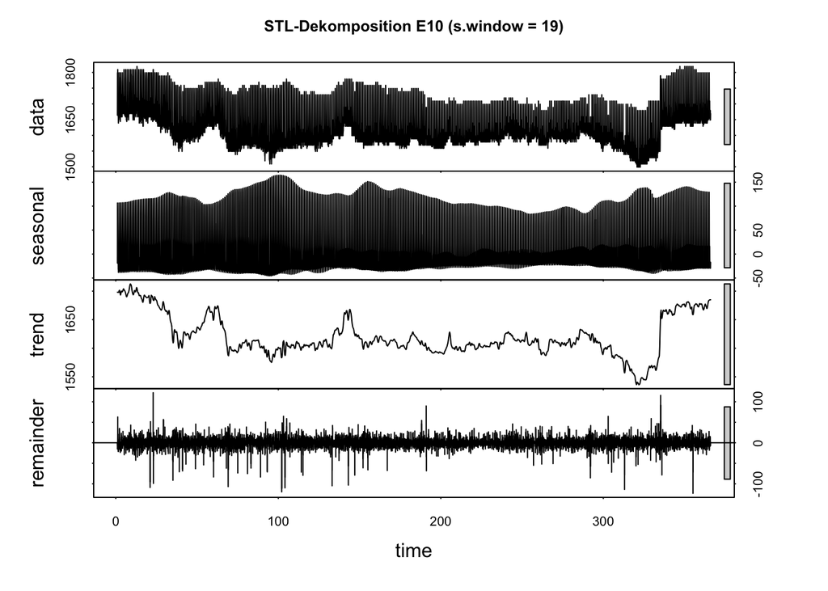

```r
price_medianByHour_e10_ts    <- ts(price_medianByHour$e10_median,    frequency = 19)
price_medianByHour_diesel_ts <- ts(price_medianByHour$diesel_median, frequency = 19)

interp_na <- function(x) {
  nas <- is.na(x)
  if (!any(nas)) return(x)
  x[nas] <- approx(seq_along(x), x, xout = which(nas))$y
  x
}

e10_clean    <- interp_na(as.numeric(price_medianByHour_e10_ts))
diesel_clean <- interp_na(as.numeric(price_medianByHour_diesel_ts))

e10_ts_clean    <- ts(e10_clean,    frequency = 19)
diesel_ts_clean <- ts(diesel_clean, frequency = 19)

# STL mit s.window = 19
stl_e10_19     <- stl(e10_ts_clean,    s.window = 19)
stl_diesel_19  <- stl(diesel_ts_clean, s.window = 19)

# STL mit s.window = "periodic"
stl_e10_per    <- stl(e10_ts_clean,    s.window = "periodic")
stl_diesel_per <- stl(diesel_ts_clean, s.window = "periodic")

# Plots
plot(stl_e10_19,    main = "STL-Dekomposition E10 (s.window = 19)")
```

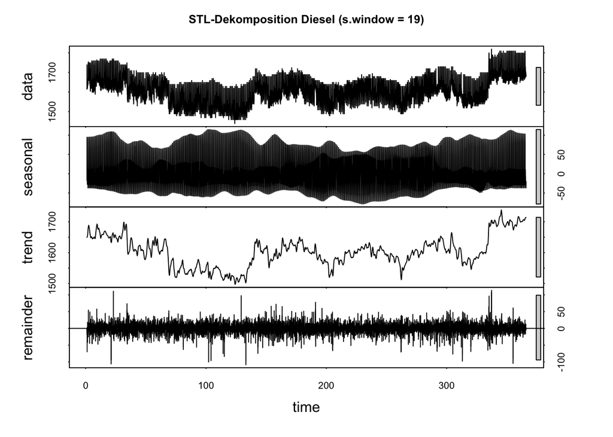

```r
plot(stl_diesel_19, main = "STL-Dekomposition Diesel (s.window = 19)")
```

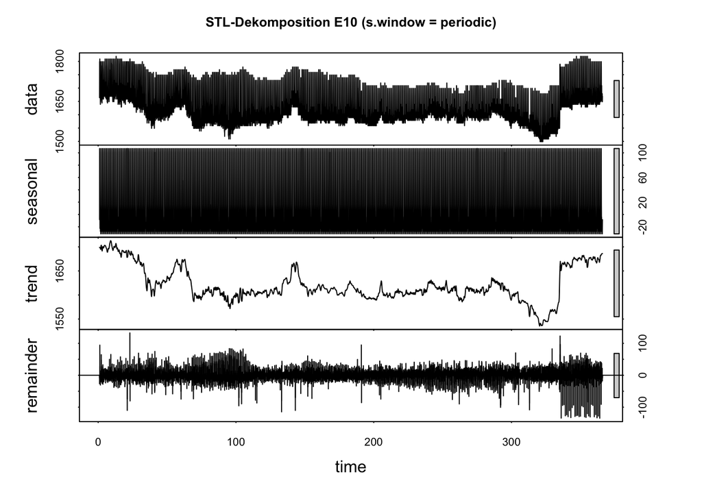

```r
plot(stl_e10_per,   main = "STL-Dekomposition E10 (s.window = periodic)")
```

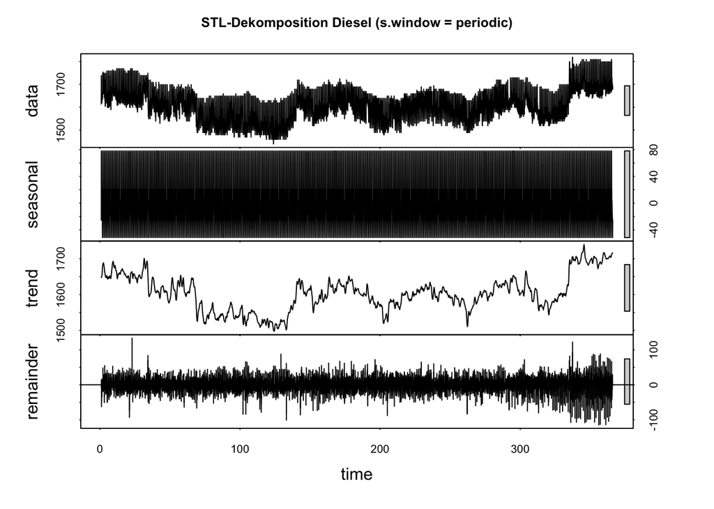

```r
plot(stl_diesel_per,main = "STL-Dekomposition Diesel (s.window = periodic)")
```

**Vergleich der beiden `s.window`-Einstellungen:**

`s.window` steuert, wie flexibel die saisonale Komponente über die Zeit sein darf. Mit `s.window = 19` (gleich der Periodenlänge) darf sich das tägliche Muster langsam über die Zeit verändern – die saisonale Komponente ist also leicht variabel. Mit `s.window = "periodic"` wird dagegen angenommen, dass das Tagesmuster über den gesamten Zeitraum **konstant** bleibt: jede Stunde hat immer denselben saisonalen Effekt, egal an welchem Tag.

In der Praxis sieht man: Bei `s.window = "periodic"` ist die saisonale Komponente glatter und regelmäßiger, das Residuum nimmt dafür etwas mehr Variation auf. Bei `s.window = 19` kann die saisonale Komponente leichte Schwankungen zeigen und passt sich etwas besser an veränderte Tagesverläufe an, das Residuum ist dafür kleiner.

## Woche 10 – 07.07.2026

**Analyse des neuen Datensatzes (01.02.- 14.06.2026)**

Zunächst importieren wir den neuen Datensatz mit denselben Tankstellen und derselben Struktur wie bisher, aber für den Zeitraum vom 1. Februar bis zum 14. Juni 2026. Wir verschaffen uns mit `str()` einen ersten Überblick und prüfen, ob die Struktur wirklich identisch zum bisherigen Datensatz `tankerkoenig` ist.

```r
tanker_neu <- read.csv("tankerkoenigSoSe2026_Feb-01-Jun-14.csv")
str(tanker_neu)
```

```
## 'data.frame':    122196 obs. of  13 variables:
##  $ X            : int  0 1 2 3 4 5 6 7 8 9 ...
##  $ id           : chr  "005056ba-7cb6-1ed2-bceb-6dbab19bed20" "005056ba-7cb6-1ed2-bceb-6dbab19bed20" "005056ba-7cb6-1ed2-bceb-6dbab19bed20" "005056ba-7cb6-1ed2-bceb-6dbab19bed20" ...
##  $ date         : chr  "2026-02-01" "2026-02-01" "2026-02-01" "2026-02-01" ...
##  $ time         : chr  "08:30" "09:30" "10:30" "11:30" ...
##  $ name         : chr  "star Tankstelle" "star Tankstelle" "star Tankstelle" "star Tankstelle" ...
##  $ brand        : chr  "STAR" "STAR" "STAR" "STAR" ...
##  $ street       : chr  "Steglitzer Damm 77" "Steglitzer Damm 77" "Steglitzer Damm 77" "Steglitzer Damm 77" ...
##  $ house_number : chr  NA NA NA NA ...
##  $ post_code    : int  12169 12169 12169 12169 12169 12169 12169 12169 12169 12169 ...
##  $ opening_time : chr  "07:00" "07:00" "07:00" "07:00" ...
##  $ closing_time : chr  "23:00" "23:00" "23:00" "23:00" ...
##  $ e10_median   : int  1709 1679 1694 1669 1699 1694 1699 1689 1694 1679 ...
##  $ diesel_median: int  1789 1679 1694 1669 1689 1699 1719 1709 1704 1699 ...
```

```r
# Zeitraum und Anzahl der Tankstellen prüfen
range(tanker_neu$date)
```

```
## [1] "2026-02-01" "2026-06-14"
```

```r
length(unique(tanker_neu$id))
```

```
## [1] 78
```

Der neue Datensatz hat dieselben 13 Spalten wie `tankerkoenig` und deckt denselben Kreis von rund 78 Berliner Tankstellen ab, diesmal für den Zeitraum 01.02.2026 bis 14.06.2026. Damit können wir ihn direkt mit den bisherigen Daten (01.02.2025–31.01.2026) vergleichen.

### Sachverhalt 1: Ein historischer Preisschock im Frühjahr 2026

Als Erstes werfen wir einen Blick auf den zeitlichen Verlauf der Tagesdurchschnittspreise im neuen Datensatz. Dazu bilden wir für jeden Kalendertag den Mittelwert über alle Tankstellen.

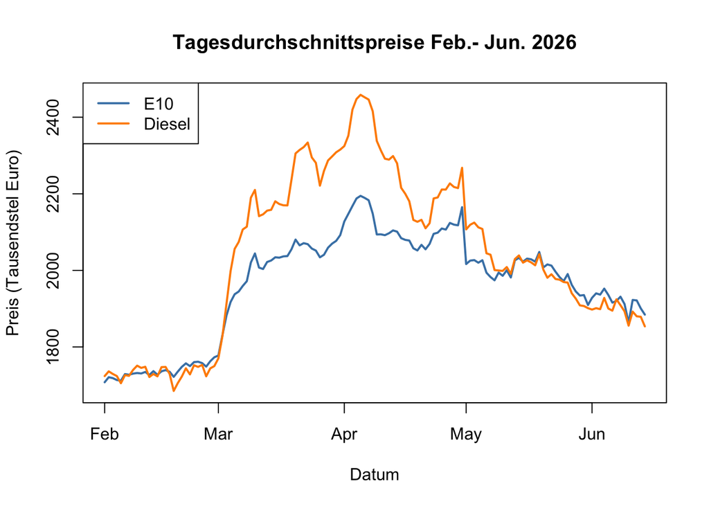

```r
tanker_neu$date <- as.Date(tanker_neu$date)

tagesmittel_neu <- aggregate(
  cbind(e10_median, diesel_median) ~ date,
  data = tanker_neu, FUN = mean
)

plot(tagesmittel_neu$date, tagesmittel_neu$e10_median,
     type = "l", col = "steelblue", lwd = 2,
     main = "Tagesdurchschnittspreise Feb.- Jun. 2026",
     xlab = "Datum", ylab = "Preis (Tausendstel Euro)",
     ylim = range(c(tagesmittel_neu$e10_median, tagesmittel_neu$diesel_median)))
lines(tagesmittel_neu$date, tagesmittel_neu$diesel_median, col = "darkorange", lwd = 2)
legend("topleft", legend = c("E10", "Diesel"), col = c("steelblue", "darkorange"), lwd = 2)
```

```r
# Ausgangsniveau Anfang Februar
mean(tagesmittel_neu$e10_median[tagesmittel_neu$date <= as.Date("2026-02-14")])
```

```
## [1] 1724.901
```

```r
mean(tagesmittel_neu$diesel_median[tagesmittel_neu$date <= as.Date("2026-02-14")])
```

```
## [1] 1730.653
```

```r
# Hoechststand
tagesmittel_neu[which.max(tagesmittel_neu$e10_median), ]
```

```
##          date e10_median diesel_median
## 64 2026-04-05   2194.617      2458.471
```

```r
tagesmittel_neu[which.max(tagesmittel_neu$diesel_median), ]
```

```
##          date e10_median diesel_median
## 64 2026-04-05   2194.617      2458.471
```

Das Bild ist eindeutig: Ab Ende Februar 2026 schießen beide Kraftstoffpreise innerhalb weniger Wochen in die Höhe. Lag der E10-Preis in der ersten Februarhälfte noch bei durchschnittlich 1725 (also 1,725 €), erreicht er am 5. April mit 2195 (2,195 €) seinen Höchststand, ein Anstieg von rund 47 Cent. Noch drastischer trifft es Diesel: von 1731 (1,731 €) Anfang Februar auf 2458 (2,458 €) am 5. April, also +73 Cent.

Zum Vergleich ziehen wir dieselbe Kalenderspanne (01.02.-14.06.) aus dem alten Datensatz von 2025 heran:

```r
tankerkoenig$date <- as.Date(tankerkoenig$date)
alt_saison <- tankerkoenig[tankerkoenig$date >= as.Date("2025-02-01") &
                              tankerkoenig$date <= as.Date("2025-06-14"), ]

vergleich_saison <- data.frame(
  Zeitraum = c("01.02.--14.06.2025", "01.02.--14.06.2026"),
  E10_Mittel = c(mean(alt_saison$e10_median, na.rm = TRUE),
                 mean(tanker_neu$e10_median, na.rm = TRUE)),
  Diesel_Mittel = c(mean(alt_saison$diesel_median, na.rm = TRUE),
                    mean(tanker_neu$diesel_median, na.rm = TRUE))
)
vergleich_saison$E10_Differenz_Cent    <- c(NA, round((vergleich_saison$E10_Mittel[2]    - vergleich_saison$E10_Mittel[1])    / 10, 1))
vergleich_saison$Diesel_Differenz_Cent <- c(NA, round((vergleich_saison$Diesel_Mittel[2] - vergleich_saison$Diesel_Mittel[1]) / 10, 1))
vergleich_saison
```

```
##             Zeitraum E10_Mittel Diesel_Mittel E10_Differenz_Cent
## 1 01.02.--14.06.2025   1661.119      1605.375                 NA
## 2 01.02.--14.06.2026   1937.218      2006.496               27.6
##   Diesel_Differenz_Cent
## 1                    NA
## 2                  40.1
```

Im direkten Vorjahresvergleich (gleicher Kalenderabschnitt 1. Februar bis 14. Juni) liegt der E10-Preis 2026 im Schnitt um rund 27,6 Cent (+16,6 %) über dem Vorjahreswert, Diesel sogar um rund 40,1 Cent (+25,0 %) höher. Das deckt sich mit Presseberichten: Ende Februar 2026 eskalierte der Krieg im Nahen Osten mit einer Blockade der Straße von Hormus, über die etwa ein Drittel des weltweiten Öltransports läuft. Das trieb den Ölpreis auf dem Weltmarkt um rund 30 % nach oben und ließ die Preise an deutschen Tankstellen auf neue Rekordstände steigen, der ADAC bezeichnete den April 2026 als teuersten Tankmonat seit Beginn seiner Aufzeichnungen [2].

### Sachverhalt 2: Diesel wird während der Krise erstmals deutlich teurer als E10

In den bisherigen Wochenaufgaben war Diesel gegenüber E10 fast immer günstiger. Wir prüfen, ob das während des Preisschocks so bleibt, indem wir die Differenz `diesel_median - e10_median` über die Zeit betrachten.

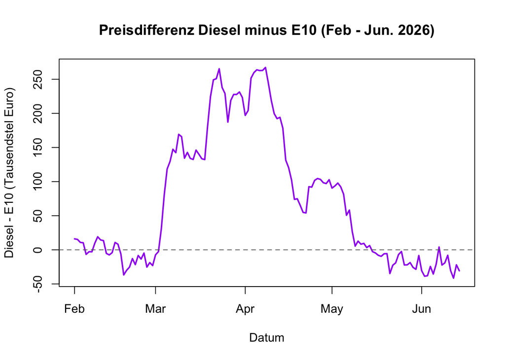

```r
tagesmittel_neu$spread <- tagesmittel_neu$diesel_median - tagesmittel_neu$e10_median

plot(tagesmittel_neu$date, tagesmittel_neu$spread,
     type = "l", col = "purple", lwd = 2,
     main = "Preisdifferenz Diesel minus E10 (Feb - Jun. 2026)",
     xlab = "Datum", ylab = "Diesel - E10 (Tausendstel Euro)")
abline(h = 0, lty = 2, col = "gray40")
```

```r
vor_krise   <- tagesmittel_neu[tagesmittel_neu$date <= as.Date("2026-02-20"), ]
hoehepunkt  <- tagesmittel_neu[tagesmittel_neu$date >= as.Date("2026-03-15") &
                                  tagesmittel_neu$date <= as.Date("2026-04-20"), ]
nach_rabatt <- tagesmittel_neu[tagesmittel_neu$date >= as.Date("2026-05-15"), ]

data.frame(
  Phase = c("Vor der Krise (01.--20.02.)", "Krisenhöhepunkt (15.03.- 20.04.)", "Nach Tankrabatt (ab 15.05.)"),
  Mittlerer_Spread = round(c(mean(vor_krise$spread), mean(hoehepunkt$spread), mean(nach_rabatt$spread)), 1)
)
```

```
##                              Phase Mittlerer_Spread
## 1      Vor der Krise (01.--20.02.)              0.1
## 2 Krisenhöhepunkt (15.03.- 20.04.)            196.6
## 3      Nach Tankrabatt (ab 15.05.)            -19.5
```

### Sachverhalt 3: Der Tankrabatt schlägt sich messbar an der Zapfsäule nieder

Am 1. Mai 2026 senkte die Bundesregierung befristet die Energiesteuer auf Kraftstoffe um rund 14,04 Cent je Liter (mit Mehrwertsteuer rund 17 Cent) [3]. Wir prüfen, ob dieser Schritt in unseren Daten als scharfer Knick sichtbar wird.

```r
uebergang <- tagesmittel_neu[tagesmittel_neu$date >= as.Date("2026-04-27") &
                                tagesmittel_neu$date <= as.Date("2026-05-06"), ]
uebergang
```

```
##          date e10_median diesel_median    spread
## 86 2026-04-27   2123.902      2227.126 103.22380
## 87 2026-04-28   2119.473      2217.809  98.33596
## 88 2026-04-29   2117.727      2214.902  97.17538
## 89 2026-04-30   2165.056      2267.855 102.79898
## 90 2026-05-01   2016.547      2107.054  90.50633
## 91 2026-05-02   2025.494      2119.168  93.67412
## 92 2026-05-03   2026.889      2124.769  97.88007
## 93 2026-05-04   2020.048      2112.453  92.40469
## 94 2026-05-05   2026.468      2108.081  81.61245
## 95 2026-05-06   1993.988      2044.683  50.69444
```

```r
rueckgang_e10    <- uebergang$e10_median[uebergang$date == as.Date("2026-04-30")] -
                     uebergang$e10_median[uebergang$date == as.Date("2026-05-01")]
rueckgang_diesel <- uebergang$diesel_median[uebergang$date == as.Date("2026-04-30")] -
                     uebergang$diesel_median[uebergang$date == as.Date("2026-05-01")]
cat("Rückgang E10 (30.04. -> 01.05.) in Cent:", round(rueckgang_e10 / 10, 1), "\n")
```

```
## Rückgang E10 (30.04. -> 01.05.) in Cent: 14.9
```

```r
cat("Rückgang Diesel (30.04. -> 01.05.) in Cent:", round(rueckgang_diesel / 10, 1), "\n")
```

```
## Rückgang Diesel (30.04. -> 01.05.) in Cent: 16.1
```

Zwischen dem 30. April und dem 1. Mai fällt der E10-Preis von durchschnittlich 2165 auf 2017, ein Rückgang von rund 14,9 Cent innerhalb eines einzigen Tages. Bei Diesel sind es sogar rund 16,1 Cent (von 2268 auf 2107). Beide Werte liegen sehr nah an der angekündigten Entlastung von rund 17 Cent brutto je Liter. Der Tankrabatt wurde damit zu einem großen Teil unmittelbar an die Verbraucher weitergegeben, auch wenn der Bundeskartellamt-Präsident davor warnte, dass Mineralölkonzerne solche Effekte nicht immer vollständig durchreichen [3].

### Sachverhalt 4: Die neue Preisregel (“Österreich-Modell”) verändert das Tagesmuster

Seit dem 1. April 2026 dürfen Tankstellen ihre Preise nur noch einmal täglich um 12 Uhr erhöhen, Senkungen bleiben jederzeit möglich [3]. Wir untersuchen, ob sich dadurch die Zahl der unterschiedlichen Tagespreisstufen je Tankstelle verändert und ob um 12 Uhr ein auffälliger Sprung entsteht.

```r
tanker_neu$hour <- as.integer(substr(tanker_neu$time, 1, 2))

vor_regel  <- tanker_neu[tanker_neu$date >= as.Date("2026-03-01") & tanker_neu$date < as.Date("2026-04-01"), ]
nach_regel <- tanker_neu[tanker_neu$date >= as.Date("2026-04-01") & tanker_neu$date <= as.Date("2026-04-30"), ]

anzahl_stufen <- function(df) {
  je_tag_station <- aggregate(e10_median ~ date + id, data = df,
                               FUN = function(x) length(unique(x)))
  mean(je_tag_station$e10_median)
}

cat("Mittlere Anzahl unterschiedlicher Preisstufen je Tag/Tankstelle im März:", round(anzahl_stufen(vor_regel), 2), "\n")
```

```
## Mittlere Anzahl unterschiedlicher Preisstufen je Tag/Tankstelle im März: 10.09
```

```r
cat("Mittlere Anzahl unterschiedlicher Preisstufen je Tag/Tankstelle im April:", round(anzahl_stufen(nach_regel), 2), "\n")
```

```
## Mittlere Anzahl unterschiedlicher Preisstufen je Tag/Tankstelle im April: 6.26
```

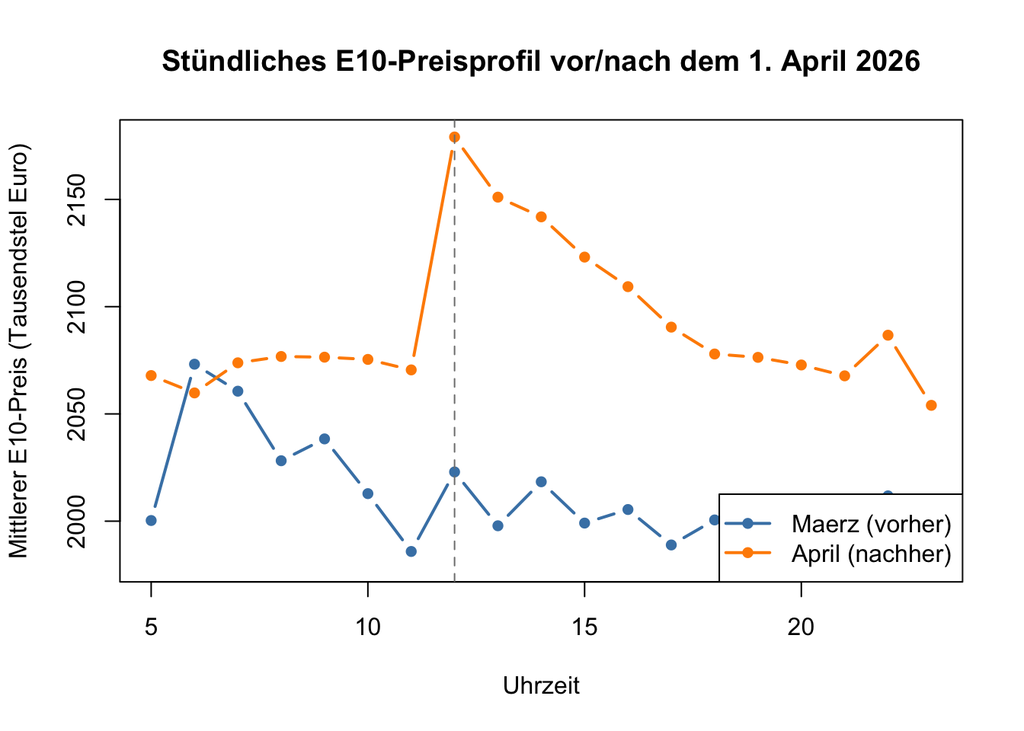

```r
stunden_vor  <- tapply(vor_regel$e10_median,  vor_regel$hour,  mean, na.rm = TRUE)
stunden_nach <- tapply(nach_regel$e10_median, nach_regel$hour, mean, na.rm = TRUE)

plot(as.integer(names(stunden_vor)), stunden_vor,
     type = "b", col = "steelblue", lwd = 2, pch = 16,
     main = "Stündliches E10-Preisprofil vor/nach dem 1. April 2026",
     xlab = "Uhrzeit", ylab = "Mittlerer E10-Preis (Tausendstel Euro)",
     ylim = range(c(stunden_vor, stunden_nach)))
lines(as.integer(names(stunden_nach)), stunden_nach, type = "b", col = "darkorange", lwd = 2, pch = 16)
abline(v = 12, lty = 2, col = "gray50")
legend("bottomright", legend = c("Maerz (vorher)", "April (nachher)"),
       col = c("steelblue", "darkorange"), lwd = 2, pch = 16)
```

```r
cat("Sprung von 11 auf 12 Uhr im März:", round(stunden_vor["12"] - stunden_vor["11"], 1), "\n")
```

```
## Sprung von 11 auf 12 Uhr im März: 37.1
```

```r
cat("Sprung von 11 auf 12 Uhr im April:", round(stunden_nach["12"] - stunden_nach["11"], 1), "\n")
```

```
## Sprung von 11 auf 12 Uhr im April: 108.6
```

Beide Kennzahlen zeigen deutlich, dass sich die Preisregel auswirkt. Die durchschnittliche Anzahl unterschiedlicher Preisstufen je Tankstelle und Tag sinkt von 10,09 im März auf 6,26 im April, die Preise ändern sich also seltener innerhalb eines Tages. Gleichzeitig entsteht im April ein auffälliger Sprung genau um 12 Uhr: Der Preis steigt von 11 auf 12 Uhr im Schnitt um 108,6 (fast 11 Cent), während derselbe Übergang im März nur 37,1 (knapp 4 Cent) betrug. Damit lässt sich der von Presse und ADAC beschriebene “Preisschock um 12 Uhr” auch in unseren eigenen Daten klar nachweisen [3][4]. Da unser Datensatz nur stündliche Mediane und keine einzelnen Preisänderungszeitpunkte enthält, ist die Stufenzahl allerdings nur ein Näherungsmaß für die tatsächliche Zahl der Preisänderungen pro Tag.

## Quellen

[1] Tankerkönig UG, URL: https://tankerkoenig.de, letzter Aufruf: 27.04.2026

[2] Statista, “Wie entwickeln sich Benzin und Dieselpreis?”, URL: https://de.statista.com/infografik/36008/entwicklung-der-spritpreise-in-deutschland/, letzter Aufruf: 05.07.2026

[3] Bundesregierung, “Maßnahmen gegen hohe Spritpreise”, URL: https://www.bundesregierung.de/breg-de/aktuelles/massnahmen-gegen-spritpreise-2410850, letzter Aufruf: 05.07.2026

[4] ADAC, “Aktueller Spritpreis”, URL: https://www.adac.de/news/aktueller-spritpreis/, letzter Aufruf: 05.07.2026